# Social economic decision-making and psychopathy: A systematic review and meta-analysis - ScienceDirect

## Figures (4)

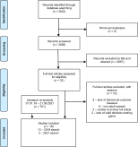

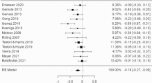

## Tables (3)

1. Table 1
2. Table 2
3. Table 3

## Extras (1)

1. Supplementary material

## [Neuroscience & Biobehavioral Reviews](https://www.sciencedirect.com/journal/neuroscience-and-biobehavioral-reviews)

[Volume 143](https://www.sciencedirect.com/journal/neuroscience-and-biobehavioral-reviews/vol/143/suppl/C), December 2022, 104966

# Review article Social economic decision-making and psychopathy: A systematic review and meta-analysis

https://doi.org/10.1016/j.neubiorev.2022.104966[Get rights and content](https://s100.copyright.com/AppDispatchServlet?publisherName=ELS&contentID=S0149763422004559&orderBeanReset=true)

Under a Creative Commons [license](https://creativecommons.org/licenses/by/4.0/)

Open access

## Highlights

**•**

Psychopathy is associated with reduced cooperation.

**•**

Psychopathy is associated with smaller offering behaviour.

**•**

No support for link of psychopathy with higher total gains.

**•**

Adaptiveness of psychopathic traits is dependent on context.

**•**

Advanced approaches enable examination of more refined motivations.

## Abstract

Psychopathy is a personality construct that encompasses a constellation of traits reflecting emotional dysfunction and antisocial behavior. This constellation has consistently been linked to poor decision-making, often focused on personal and monetary gains at the others’ expense. However, there remains a lack of a systematic examination of how psychopathy is related to the prospect of obtaining monetary gains as a function of social context. Therefore, we conducted a series of meta-analyses to elucidate these relationships. Our findings indicated that elevated levels of psychopathy are related to a reduced tendency to cooperate with others, and no difference in the extent to which knowledge of others’ retaliation possibilities informs decision-making. However, the type of social economic decision-making game employed moderated the association between psychopathic traits and total gain obtained, suggesting that context plays a key role in moderating the link between psychopathic features and decision-making. These findings advance our understanding of psychopathy and open new avenues for research on adaptive and maladaptive social behavior in individuals with high levels of psychopathic traits.

## Keywords

Psychopathy

Cooperation

Decision-making

Antisocial behavior

Neuroeconomics

## 1. Introduction

Psychopathy is a multidimensional construct encompassing a collection of personality traits believed to reflect disturbed interpersonal functioning (e.g., manipulativeness, grandiosity), affective disruptions (e.g., lack of empathy, guiltlessness), inclination toward an erratic lifestyle (e.g., irresponsible behavior, sensation seeking), and the engagement in antisocial acts (e.g., criminality)(Blair, 2013a; Hare, 2003; Hoppenbrouwers et al., 2016). Although psychopathy has often been approached as a categorical construct in offender populations, psychopathic traits have been found to be normally distributed across the population (DeMatteo et al., 2006, Guay et al., 2007, Lockwood et al., 2013, Murrie et al., 2007, Neumann and Hare, 2008, Seara-Cardoso et al., 2012, Seara-Cardoso et al., 2022). Such findings have led researchers to argue for a dimensional approach to psychopathy instead (e.g., Blackburn, 1988; Eysenck, 1951, Eysenck, 1994; Stone, 1993; Widiger, 1993; Widiger and Costa, 1994). Psychopathy assessments are particularly valuable due to their high power for predicting harmful behaviors and the severity of outcomes (e.g., Hawes et al., 2013; Lynam et al., 2007; Schmidt et al., 2006; Stafford and Cornell, 2003). While psychopathic traits tend to decline with age (Cutler et al., 2021, Gill and Crino, 2012, Huchzermeier et al., 2008), psychopathy has been found to have a developmental constituent, and some characteristics remain relatively stable from childhood into adulthood (Glenn, 2019, Lynam et al., 2007, Muñoz and Frick, 2007). Psychopathic traits in youth seem to (partially) predict maladaptive and disruptive behaviors later in life (Glenn, 2019, López-Romero et al., 2014, Lynam et al., 2007, Lynam et al., 2009).

It is evident that the maladaptive behaviors seen in individuals with psychopathic tendencies have great impact on society and managing antisocial behavior could be facilitated by procuring insight into the underlying (biopsychological) mechanisms, their moderators, and their real-world correlates (e.g., Jurjako et al., 2020). One proposal has been that disturbances in multiple biopsychological mechanisms that underlie interpersonal-affective functioning drive some of the behaviors typically associated with psychopathy (e.g., lack of empathy, reduced responding to distress in others)(Berg et al., 2013; Blair, 2007; Gervais et al., 2013; Gong et al., 2019). It is thought that such dysfunctions may ultimately affect social decision-making in psychopathy, often reflected in choices that lead to personal gains (e.g., assaulting someone to steal money) but also to negative outcomes for others (e.g., traumatic memories of the assault for the victim) (Blair, 2013b; Brazil et al., 2011). Importantly, however, understanding such poor social economic decisions requires us to look beyond established neurobiological and cognitive-affective accounts of psychopathy, as research has shown that social economic decisions are deeply rooted in complex social principles, such as trust, reciprocity, and altruism (Bowles and Gintis, 2011, Kurzban, 2003, Queller, 1985, Thielmann et al., 2020). The excessively reward-driven social behaviors often linked to psychopathy suggests that these principles may be violated systematically by individuals with elevated psychopathic tendencies.

Research on social economic decision-making typically involves using paradigms that replicate social exchanges under controlled conditions. These paradigms are referred to as social economic ‘games’ and intend to mimic social encounters that require participants to make decisions concerning the allocation of monetary incentives among all involved individuals (i.e., ‘players’). One example of such a paradigm is the Ultimatum Game (UG; Güth et al., 1982), in which one player is asked to divide a given amount of money between themselves and another player. Following the proposed split, the recipient of the offer is given the choice to reject or accept the offer. Rejection results in none of the players receiving money, whereas acceptance results in each of them receiving the agreed-upon amount. Completely rational decision-makers are expected to accept any offer exceeding zero. However, research findings indicate that about half of healthy participants reject offers that fall below 30–40% of the total amount (Bolton and Zwick, 1995, Camerer et al., 2003, Güth et al., 1982, Koenigs and Tranel, 2007, Oosterbeek et al., 2004, Opaluch and Segerson, 1989, Sanfey et al., 2003, Van’t Wout et al., 2006).

Importantly, the conclusions of these studies depend on several moderating factors that have been outlined in the literature. These can be broadly categorized as pertaining to the nature of the outcome variable, task characteristics, or potential sources of individual differences. In the following sections, we discuss each category with an emphasis on its relevance for understanding social decision-making in relation to psychopathy. First, we explain the nature of three outcome measures commonly encountered in the literature. We go on to introduce and discuss the characteristics of the different paradigms employed. Finally, we elaborate on several moderators pertinent to our understanding of social behavior of psychopathic individuals across a range of social economic decision-making contexts.

### 1.1. Outcome measures

Several outcome measures of social economic decision-making have been identified and provide insight into different aspects of social behavior. Three key measures that appear in the literature are 1) the willingness to cooperate with others, 2) the inclination to offer money to others, and 3) the potential gain obtained at the end of a task. Throughout the following paragraphs, we present these measures within a theoretical framework of psychopathic traits.

#### 1.1.1. Cooperation

Cooperation is a vital aspect of social decision-making as much of our successes and failures are dependent on the pro- and antisocial decisions made by ourselves and others. Cooperation refers to behavior aimed at achieving common goals, irrespective of the consequences for the individual (Rand and Nowak, 2013). It has been argued that human cooperation is a tenant for the success of our species (Curry, 2016, Nowak and Coakley, 2013, Seabright, 2010, Szathmáry and Smith, 1995). Yet, collective and individual interests frequently require divergent behavioral choices (Rand and Nowak, 2013). Whereas cooperation tends to bring about the most desirable outcomes for the population at large, defective behavior maximizes the individual payout. The cost and benefit of the two behavioral choices are contingent on the social situation in which they occur. For instance, defection can be particularly effective in social contexts where cooperation is the norm (Brown and Vincent, 2008, Cowen and Sutter, 1999, Ohdaira, 2019, Smaldino et al., 2013).

The mechanisms driving the decision-making in different contexts remain a topic of debate. One proposal is that self-interest lies at the heart of social economic decisions, with cooperative behavior becoming more valuable as the number of interactions with the other increases (Cohen, 1998). This view postulates that individual cost-benefit analyses drive cooperative efforts (Bowles and Gintis, 2005, Diekmann and Lindenberg, 2015, Labarre, 2007), a hypothesis that has received criticism based on evidence showing that individuals choose to cooperate despite great personal costs (Fehr and Gächter, 2002, Isaac and Walker, 1988, Ostrom and Walker, 1991). Alternative accounts are rooted in the idea of social preference, postulating that motivations beyond material self-interest drive human behavior (Fehr and Fischbacher, 2002). People have been found to consider the payoff of a reference group (e.g., Fehr and Schmidt, 1999), as well as the intention of the payoff (e.g., Falk et al., 2008). The experience of guilt and perception of fairness fall under the idea of social preference, and have been used to explain why individuals choose to cooperate or not. In this context, guilt is the negative emotional reaction to failure of living up to others’ expectations. Thus, guilt is an experience that is based on second-order beliefs rather than factual information (Baumeister et al., 1994, Chang et al., 2011, Khalmetski, 2016). The anticipated guilt of a prospective decision is proposed to moderate decision-making and promote cooperative behavior. Another line of reasoning suggests fairness perceptions to be a key determinant of choices made in social economic decision-making games (Bolton and Ockenfels, 2000, Brosnan, 2006, Fehr and Schmidt, 1999). The extent to which individuals are motived to obtain fair outcomes can be seen as a function of how inequity-averse they are (Fehr and Schmidt, 1999). Likewise, individuals who avoid inequity in their decision-making are likely to behave more cooperative across various social contexts. Some findings support this notion, and individuals who value their payouts relative to that of others’ have been found to be more willing to sacrifice their own payouts, demonstrating cooperative behavior (Brosnan, 2006, Chang et al., 2011).

Taken together, there are indications for a potential link between cooperative behavior and psychopathy, but the nature of the relationship across models of social economic decision-making remains unclear. Importantly, the trade-off between obtaining outcomes that benefit multiple individuals versus the self, is also influenced by the number of resources that need to be sacrificed, i.e., the offers that need to be made.

#### 1.1.2. Offer size

Another class of outcome measures in social economic decision-making is the size of offers, usually in the form of monetary rewards. This measure concerns the amount of an available resource that individuals are willing to forgo during social exchanges. While many studies place the participant in the role of the recipient, others have asked participants to pose offers to others themselves, requiring them to distribute a given amount of money, for example (e.g., Geniole et al., 2013; Osumi and Ohira, 2017). Differences in offering behavior across social economic decision-making games allow for comparison of the diverging hypotheses and provide valuable insight into the ways individuals make their decisions in social economic contexts. One way to address this is by comparing the Dictator and Ultimatum games, with the latter involving reciprocal actions of the other player, whereas the former does not (Andreoni and Petrie, 2004, Hoffman et al., 1994, Izuma, 2017, Rege and Telle, 2004). The amount offered by the proposer in the Dictator Game is presumed to reflect a prosocial sentiment, such as fairness or guilt, while in the Ultimatum Game, the amount offered can be a product of both prosocial and strategic considerations. Both sense of fairness, and the aversion to experiencing guilt have been proposed to drive what individuals are willing to offer others across social economic decision-making games. Each of these strategies may be implemented by different, but interacting, biopsychological mechanisms (van Baar et al., 2019), and have been linked to psychopathy (Driessen et al., 2021).

Two potential motivations behind offering behavior in relation to psychopathy may be conceived. On the one hand, individuals with elevated levels of psychopathy may be driven by immediate reward and inclined to pose low offers (Blair et al., 2006; Blair et al., 2004; Snowden and Gray, 2011), leading to immediate and moderate payouts. On the other, individuals with elevated levels of psychopathy may take personal relations into account, such as potential retaliation following a low offer, which would call for a more generous offering behavior. By analyzing offer size as a function of psychopathy scores, Osumi and Ohira (2017) found that interpersonal and affective traits linked to psychopathy were associated with lower offers in the Dictator compared to the Ultimatum Game. This suggests that fairness considerations affect utilitarian behavior in individuals scoring high on interpersonal-affective traits.

Up to this point, we have discussed potential motivators and strategies for cooperative and offering behavior and have highlighted possible links with psychopathy. However, one cannot make strong claims about the efficacy of the employed strategies without considering the characteristics of the potential outcomes. Therefore, we will next consider the importance of the total gain that can be obtained at the end of social economic decision-making games.

#### 1.1.3. Total gain

Social economic decision-making games involve the exchange of currencies. Individuals who do particularly well at accumulating said currencies frequently receive higher monetary payouts upon completing the experiment, to incentivize performance and imitate realistic monetary interactions (Davis et al., 1993, Hertwig and Ortmann, 2001). As such, the total gain of a particular currency provides insight beyond the evaluation of overall cooperative or defective behavior, speaking to the efficacy of individuals in obtaining favorable outcomes for themselves. Yet, most cooperative games are contingent on the actions of both parties involved and only in exceptional cases is the total gain a direct consequence of the individual’s behavior. However, influences of individuals’ behavior on the responses of opposing actors may similarly affect the total gain and speak to the efficacy of obtaining desired rewards in a social economic context. As such, in many paradigms the total gain obtained at the end of a task is related to the behavioral choices made throughout that task and thus may provide valuable insight into the decisions in social economic encounters.

Examining the impact that the prospect of reward has on social economic decision-making as a function of psychopathic traits becomes particularly interesting in light of reward-based learning deficits of psychopathic individuals (Gregory et al., 2015, Lykken, 1957). It has been suggested that individuals with elevated levels of psychopathic traits demonstrate heightened sensitivity to rewards (e.g., Mokros et al., 2008), i.e., they show an increased motivation to obtain rewards for themselves (Gorenstein and Newman, 1980). This reward sensitivity model accounts for findings of increased greed in relation to psychopathy (Driessen et al., 2021, Seuntjens et al., 2015). Evidence indicating that individuals with high levels of psychopathic traits are indeed hypersensitive to rewards has been provided by behavioral as well as neurobiological studies (Blair, 2008; Buckholtz et al., 2010; Everitt et al., 2008).

Accordingly, we may assume that individuals scoring high on psychopathic traits employ decision-making strategies that are aimed at obtaining large gains for themselves at the expense of others. There is some supporting evidence suggesting that offenders with elevated levels of psychopathy can indeed manage to obtain larger gains for themselves while playing social economic games (e.g., Mokros et al., 2008). Moreover, the rationale of the ‘successful psychopath’ suggests that psychopathy entails several positive factors, such as heightened resilience, that can foster positive outcomes for individuals who do not exhibit the heightened antisocial impulses (e.g., Lasko and Chester, 2021). Thus, there are indications that levels of psychopathic traits covary with the efficiency of obtaining personal gains in the context of social economic decision-making.

#### 1.1.4. Interim summary

Research involving social economic decision-making paradigms offer rich information about the behavior of individuals in social economic contexts. Cooperation, offering behavior, and total gain obtained during the task are of particular interest in the examination of social economic interactions. Cooperation, defined as behavior aimed at achieving common goals, often emerges from a conflict of collective and individual interests (Rand and Nowak, 2013). Given the importance of cooperative behavior for society, learning about the conditions under which individuals, and psychopathic individuals, act in cooperative ways is of substantial relevance. Examining offer size, defined as the amount of a particular currency that individuals are willing to forgo during social exchanges, permits further insight into the processes at play during social decisions. Specifically, a comparison of offers between games in which the other actor is or is not capable to retaliating provides further insight into the behavioral motivations of individuals with elevated levels of psychopathic traits. At last, total gain captures the efficacy of individuals’ at obtaining desired resources and is closely related to the debate whether psychopathic traits encompass aspects that may be advantageous in particular circumstances. Taken together, this combination of variables pertaining to social economic interactions provides a more comprehensive picture of the factors that contribute to the behavioral abnormalities of individuals with psychopathic tendencies. Meaningful conclusions about the role of psychopathic traits in social economic contexts require the consideration of several variables, and the subtle differences across paradigms are important to consider when comparing findings in the literature. We turn toward a more detailed description of paradigms used to assess social economic interactions.

### 1.2. Social economic decision-making paradigms

Increasingly complex paradigms have been developed to examine decision-making of individuals in social economic contexts. Whereas a comprehensive discussion of these games is beyond the scope of the present paper, we provide a brief introduction of the most common games social economic decision-making literature (for more detail, see Van Dijk and De Dreu, 2021). These paradigms concern the Prisoner’s Dilemma, the Ultimatum Game, the Dictator Game, and the Trust Game.

#### 1.2.1. Prisoner’s Dilemma

The Prisoner’s Dilemma (PD; Tucker, 1950) is a one-shot game used to study the trade-off between choosing out of self vs. group interest. The game is played by two individuals whose choices can yield the following outcomes: i) both players defect and must serve another two years in prison, ii) both players cooperate and must serve a reduced sentence of one year, and iii) one cooperates and the other defects, the one who cooperates needs to serve another three years while the one that defects is set free. The monetary equivalent of the prisoner’s dilemma replaces the hypothetical prison sentence with monetary reward, while the contingencies remain the same. The PD constitutes a cooperative dilemma in the sense that, independent of the other player’s response, defection is always the most adaptive response for the individual. Although mutual cooperation can be beneficial, exploitation of someone else’s cooperative behavior is even more so for the individual (Denison & Muller, 2016).

#### 1.2.2. Dictator Game

The Dictator Game (DG) is an economic game in which one active player (the Dictator) has to determine the split of an endowment with a second passive player (the Recipient)(Forsythe et al., 1994). The central question that is studied using a DG is: how much is a *Dictator* willing to give? Maximizing own gains can be achieved by keeping the entire endowment to oneself. However, there is ample evidence that zero-offers are rarely the case during DGs (e.g., Engel, 2011; Forsythe et al., 1994). This observation suggests that dictators may be willing to give up part of their earnings because they care about others’ welfare or are concerned about the equality of the resulting allocation, which aligns with the idea of social preference in social economic interactions (Engel, 2011).

#### 1.2.3. Ultimatum Game

The Ultimatum Game (UG) involves a *Proposer,* who is asked to split an endowment with a second player, and a *Responder*, who can accept or reject any offer (Harsanyi, 1961). If the Responders accepts the offer, each player receives part of the endowment according to the distribution proposed in the offer. When the offer is rejected, neither of the two players receives any money. In each round, the Proposer is required to make either a hyperfair/fair or an unfair offer. In contrast, the Responder can choose between four distinct strategies: a) reject all offers b) accept all offers c) accept only fair offers d) accept only unfair offers. Note that the strategies are based on theory and that participants might vary their strategy across trials and contexts in experimental settings. Although rational Responders are expected to accept any offer exceeding zero, several studies have demonstrated that about half of the participants tend to reject offers falling below 30–40% of the total amount (e.g., Bolton and Zwick, 1995; Koenigs and Tranel, 2007; Oosterbeek et al., 2004).

#### 1.2.4. Trust Game

The traditional Trust Game (TG) was designed to assess the relevance of trust for making economic decisions (J. Berg et al., 1995; Brülhart and Usunier, 2012). The TG involves two participants who take the roles of Investor and Trustee. On each trial, the Investor is endowed with a certain number of coins (e.g., 10 coins) and may decide to invest nothing or a part of the endowment in the Trustee, while retaining the remainder. The Investor knows that the investment will be multiplied with a stable factor (e.g., ×4) and the sum (40 coins) will be in the hands of the Trustee. The Trustee can then choose to return any number of coins to the Investor but does not have to do so. The amount passed by the Investor is said to capture trust, “a willingness to bet that another person will reciprocate a risky move (at a cost to themselves)”, and the amount returned by the Trustee to capture trustworthiness (Camerer, 2003).

Several alternatives of the traditional TG have been introduced, with the Hidden Multiplier Trust Game (HMTG) being one of the more recent ones (van Baar et al., 2019). This version uses an alternating multiplier that multiplies the investment by a factor of either 2 or 6 on half the trials, and by a factor of 4 on the other half of the trials. The change in the multiplier remains hidden to the Investor, who is led to believe the multiplier remains at × 4 in all trials. The Trustee, in turn, is aware of the Investor’s ignorance. This information asymmetry results in different predictions of Trustee's behavior based on different moral strategies. More specifically, the HMTG allows for differentiation between a guilt-averse and an inequity-averse strategy (van Baar et al., 2020). Thereby, the HMTG is an adapted TG that is particularly useful for differentiating between distinct moral strategies (Driessen et al., 2021).

#### 1.2.5. Interim summary

There are several games that can be employed to study social economic decision-making. The PD is characterized by the fact that defection leads to the most desirable outcome for an individual, irrespective of the other’s response. Adaptations of the PD allow for repeated interactions that make it possible to incorporate the importance of social reputation. The UG requires an agent to consider the behavior of a second player to obtain benefits. One discerning characteristic of the UG is that the second player takes an active role and can punish the other player for making uncooperative decisions. The DG is an alternation of the traditional UG that does not involve an active role for the second player, who can do nothing but accept the proposed offer. This makes a comparison of UG and DG particularly interesting, as the former allows for retaliation whereas the latter does not. A paradigm that does particularly well in modelling the reciprocal actions of individuals is the TG, where an active Trustee receives the opportunity to return a chosen amount following multiplication of the investment that was made by an Investor. Taken together, various games have been introduced to address distinct aspects of social economic decision-making. Importantly, it should also be considered that the employed paradigm is not the only source of variability across studies of social economic decision-making in relation to psychopathy. The conceptualization of psychopathy also differs across studies and could have a large effect on the findings. In fact, it has been shown that the same experimental data can yield opposing results depending on the psychopathy framework used (Baskin-Sommers et al., 2011). Therefore, we will consider the importance of the conceptualization and type of assessment of psychopathy next.

### 1.3. Psychopathy: Conceptualization and assessment

Over the years, a variety of different conceptualizations of psychopathy have been proposed (for an overview, see Brazil and Cima, 2016). These theories tend to differ in terms of which features are central to psychopathy, how such features are inter-related, and how they should be measured. The following paragraphs describe the contemporary conceptualizations and associated measures of psychopathy and highlight the importance of considering the differences across the social economic decision-making literature. In addition, the relevance of gender in the context of psychopathy is highlighted.

#### 1.3.1. Contemporary conceptualizations of psychopathy

Among the various conceptualizations, that of the two-factor model dates back to the early work of Harpur et al. (1989). This traditional theoretical framework distinguishes between two moderately correlated overarching dimensions (Hunt et al., 2015). Factor 1 (F1) encompasses interpersonal and affective components (e.g., callousness, shallow affect), whereas Factor 2 (F2) comprises antisocial and impulsive traits (e.g., impulsivity, criminality; Hare, 1999; Hare et al., 1991; Harpur et al., 1989). Several lower-order facets have been identified within these two broad dimensions, but the simplicity of the two-factor model has contributed to it being among the most widely investigated frameworks to date (see, Fowles, 2011). Accordingly, this two-factor framework is incorporated in the most widely used and well-validated measure of psychopathy, the Psychopathy Checklist-Revised (PCL-R; Hare et al., 1990). The PCL-R assesses F1 and F2, as well as the four facets (interpersonal, affective, lifestyle and antisocial) that have been derived from factor analyses (Hare et al., 1990). Since the PCL-R is time-consuming and its application outside the forensic context limited, other self-report measures have been introduced. Some of which have been designed to resemble the PCL-R (e.g., the Levenson Self-Report Psychopathy Scale; Levenson et al., 1995) and the Self-Report Psychopathy Scale (SRP-III; Williams et al., 2007), while others have been developed independently (e.g., the Psychopathic Personality Inventory-Revised; Lilienfeld and Widows, 2005). An extensive amount of research has assessed the cluster of factors and the ambiguity thereof is reflected in the diverse factor structures observed in the literature (Cooke and Michie, 2001, Drislane et al., 2014, Flórez et al., 2020, Hare, 1985, Hare, 1996, Tsang et al., 2018). Although F1 and F2 are represented within the three-factor structure of the PPI for instance (Drislane et al., 2014, Patrick, 2006, but see Neumann et al., 2008, for an alternative factor structure), some differences in the conceptualization and operationalization of F1 exist (Hunt et al., 2015). Whereas PCL-R F1 captures interpersonal and affective traits such as lack of empathy and callousness (Hare and Neumann, 2005), the PPI F1 incorporates adaptive aspects such as fearlessness and heightened stress capacity (Benning et al., 2003, Miller and Lynam, 2012). The divergent conceptualization of F1 psychopathy is reflected in findings of low correlations of F1 scores of the PCL-R and the PPI (Pearson correlation coefficients ranged from .15 to .24; Malterer et al., 2010; Poythress et al., 2010).

Patrick et al. (2009) outlined another framework of psychopathy with three factors *meanness, boldness,* and *disinhibition* of the Triarchic Psychopathy Measure (TriPM; Patrick et al., 2009). The TriPM is a self-report measure that is divided into three scales. The meanness scale encompasses traits such as callousness, aggression, and excitement seeking behavior. Boldness, in turn, was developed based on the fearless dominance subscale of the PPI and captures traits of high dominance and low anxiety. The third factor, disinhibition reflects tendencies of impulsive and hostile behavior. All in all, the intercorrelations of the scales are weak to moderate (Patrick et al., 2009, Patrick and Drislane, 2015). One important characteristic of the TriPM that distinguishes it from the PCL-R for instance, is that it incorporates characteristics that are thought to be adaptive in certain contexts, such as stress immunity, social influence, emotional resilience (Evans and Tully, 2016). Therefore, it is not surprising that small to modest correlations to the PCL-R have been reported. Taken together, there are significant differences across measurements of psychopathy, reflected in intercorrelations and diverging factor structures. Striving to obtain an accurate view of how psychopathic traits are related to social economic behavior, consideration of these differences is essential. Moreover, there are strong rationales as to why differences between the scales are expected when observing social behavior.

#### 1.3.2. Psychopathy measures

Despite the conflict among distinct conceptualizations of psychopathy, the substantial predictive value of psychopathy for outcomes such as violent behavior and crime make the assessment thereof a vital objective. The PCL-R has been used extensively and is regarded the gold standard of assessing psychopathy in forensic settings (Hare and Neumann, 2008). This assessment tool is rather elaborate and incorporates interviewing procedures as well as a review of official file records. Thus, the use beyond forensic contexts has been limited and differences between measures may be responsible for differences in findings concerning cooperative behavior. Some evidence supportive of this idea has been presented by Rilling et al. (2007), whose findings were significant for LSRP but not for PCL-R scores. An extensive discussion of the differences of distinct measures is beyond the scope of the present analysis and for an extensive comparison we refer to Tsang et al. (2018). Moreover, there has been ongoing debate about the conceptualization of psychopathy and the centrality of its components. Whereas existing measures tend to agree on the relevance of disinhibition, manipulativeness, callousness, and egocentricity, they differ in their consideration of adaptive features, encompassing emotional resilience, fearlessness, and social potency. Some researchers contend that findings of limited associations between the facets boldness and fearless dominance with well-established psychopathy correlates are indications of the components’ non-centrality (Crowe et al., 2021, Gatner et al., 2016, Lynam and Miller, 2012, Miller and Lynam, 2012), others claim that classic accounts describe adaptive features with relevance to psychopathy (Lilienfeld et al., 2012, Lilienfeld et al., 2016), e.g., in the detailed descriptions in *The Mask of Sanity* (Cleckley, 1941). This controversy is reflected in modern psychopathy measures.

In general, the literature on differences in social economic decision-making as a function of psychopathy measurement is limited. Turning to the behavioral assessments, several components of social behavior have been addressed across the different paradigms, which provide insight into the ways individuals with elevated levels of psychopathic traits behave in social contexts. The following paragraphs are dedicated to introducing the different variables of interest that have been addressed in the literature on social economic decision-making in relation to psychopathy. Current conceptualizations of psychopathy, as described in the preceding paragraphs, are predominantly based on the expression of psychopathic traits in male offenders (De Vogel and Lancel, 2016, Wynn et al., 2012). Potential gender-specific manifestation of psychopathic traits warrants the consideration of gender when evaluating social economic interactions.

#### 1.3.3. Gender as a potential confound

Historically, the majority of psychopathy literature has focused on the expression of psychopathic traits in men (Cale and Lilienfeld, 2002, Hare, 1982, Harris et al., 1994, Hart and Hare, 1989). More recently, scholars have expressed increased interest in the expression of psychopathy in women. Findings of differences in prevalence of psychopathic traits between genders (Hare, 1996, Hare, 1998, Hart et al., 1992) have led researchers to question the assumption that psychopathic traits manifest independent of gender (Cale and Lilienfeld, 2002, De Vogel and Lancel, 2016, Neumann et al., 2012, Nicholls et al., 2005). One potential explanation for a diverge in prevalence is that gender influences the expression of psychopathic traits. For instance, women may exhibit different ways of manipulating others, being more flirtatious in their attempts to deceive (Forouzan and Cooke, 2005). Some findings have indicated general differences in understanding of morality between men and women with elevated psychopathic traits (Efferson and Glenn, 2018, Graham et al., 2011). All in all, there is considerable controversy about gender-based differences in the expression of psychopathic tendencies. This warrants an investigation of potential gender-related differences in the expression of psychopathy across social economic decision-making games.

#### 1.3.4. Interim summary

There has been substantial debate on the conceptualization of psychopathy, a debate that is reflected in the differences of common psychopathy measurements. Different measures suggest different factor structures and there is a lack of agreement which factors are at the core of psychopathy. It follows that these differences may contribute to the heterogeneity of findings between psychopathic traits and behavioral outcomes in experiments and applied contexts. Moreover, the literature on psychopathy has been historically based on male subjects, and research on the expression of psychopathic traits in females has picked up in recent decades only. Existing disagreements about the relevance of gender to psychopathic deficits warrant a look at the effect of gender on the relationship between psychopathic traits and social economic decision-making.

### 1.4. Goals

The main aim of the current meta-analytical study was to examine the relationship between psychopathic traits and social economic decision-making. In order to address the complexity of social decision-making, we focused on three key aspects of decision-making: cooperation, offer size, and total gain. Our primary hypothesis is that psychopathic traits are negatively associated with cooperative behavior. Despite substantial disagreement on the etiology of psychopathic deficits and its core components, the different conceptualizations agree on a negative relationship between psychopathic traits and cooperation. This is rooted in the correlates of psychopathy with antisocial behavior, fairness violations, and egocentric behavioral tendencies (Brazil and Cima, 2016; Hamilton et al., 2015; Hare and Neumann, 2008). Our exploratory analyses addressed ongoing controversies of great relevance to the question how psychopathic traits influence social economic decision-making. Given the substantial disagreement within the literature on some of these factors, we refrained from formulating hypotheses about the direction or presence of the effect on outcome variables besides cooperation, and that of several moderators.

## 2. Methods

### 2.1. Search strategy

PubMed was used to search for articles using the following combination of terms: “bargaining game” OR “coordination game” OR “dictator game” OR “economic decision” OR “economic decision making” OR “matching pennies game” OR “moral decision making” OR “moral strategy” OR “reciprocal exchange game” OR “social decision making” OR “social decision strategy” OR “trust game” OR “ultimatum bargain” OR “ultimatum game” AND “antisociality” OR “antisocial” OR “psychopathy” OR “psychopaths” OR “psychopathic traits” OR “forensic psychiatry”. Relevant articles were selected based on the following inclusion criteria:

**1.**

The studied population should be limited to adults, all subjects being at least 18 years of age.

**2.**

Samples of all kinds were allowed in the current investigation, including undergraduate, community, or incarcerated samples. Inclusion was limited to participants with normal cognitive functioning (no drug abuse, no brain damage, no major Axis-I psychiatric disorder). If this criterion is merely met by a subsample of a study, this subsample is eligible to be included.

**3.**

Only studies with a sample size N > 10 were included (Hedges, 1982).

**4.**

Studies should have employed well-validated psychopathy measures.

**5.**

The experimental paradigm should concern validated social economic decision-making games or another form of decision-making scenario resembling the interaction of two or more individuals.

**6.**

Behavioral data should be available for at least one of the target dependent variables: cooperation, offer size, and total gain.

**7.**

Articles should be original (primary) research published in peer-reviewed journals.

**8.**

Full-text availability of the articles in any of the three languages English, German, or French should be given.

### 2.2. Search results

Our electronic search identified 3033 records. Four duplicates were removed and following a screening of title (2840), abstract (157), or full text (19) we obtained a sample of 13 studies. The majority of the studies excluded during full-text screening had to be removed due to a lack of appropriate behavioral outcome measures that would allow for quantitative analyses of our dependent variables. Two years after the initial literature search in September 2019, we performed an additional search (in September 2021) to include articles that were published in the meantime. The final selection entails 16 studies (see Fig. 1). General characteristics, findings, and methodology of the studies included in the analyses are depicted in Table 1. Of these records, thirteen were suitable for analyses of cooperation, seven for analyses of offer size, and six for analyses of total gain (see Table 2).

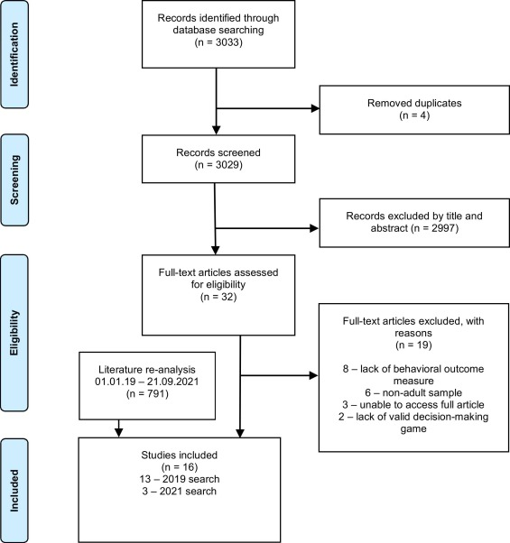

Fig. 1. PRISMA flow chart depicting the search strategy and selection of studies, Note. The PRISMA flow chart depicts the study selection process, including the original literature extraction in September 2019, and the re-analysis in September 2021.

Table 1. Detailed depiction of studies, methodology, included participants, the employed task, measurement scale, and their main findings respectively.

| Study | Paradigm | Sample | Measure | Main Findings |
| --- | --- | --- | --- | --- |
| Balafoutas et al. (2021) | Prisoner's Dilemma & Trust Game | 145 participants (male; prisoner) | LSRP | Cooperation is associated with lower LSRP scores; Cooperation is associated negatively with primary and secondary psychopathy scores. |
| Driessen et al. (2021) | Hidden Multiplier Trust Game (recipient) | 86 participants (36 males; online) | SRP-SF | Lower inequity aversion in individuals with elevated affective or antisocial psychopathic traits; no link between guilt aversion and psychopathic traits. |
| Geniole et al. (2013) | Dictator Game | 201 participants (101 males; community) | PPI-R | Cooperative behavior was negatively associated with the fearless dominance facet of psychopathy, independent of testosterone levels. |
| Gervais et al. (2013) | Prisoner Dilemma (one-shot) | 105 participants (70 males; community) | LSRP | Cooperative behavior was negatively associated with factor 1 psychopathy on low-value social interactions; LSRP score associated with total profit, more attractive participants received more cooperati… |
| Gillespie et al. (2013) | Dictator Game & Ultimatum Game (in- and outgroup) | 60 participants (10 males; community) | LSRP | No differences in offers across games; no association of primary or secondary psychopathy with offer size; no differences in giving behavior for in – and – outgroup; no interaction effects of psychopa… |
| Gong et al. (2019) | Trust Game | 63 participants (13 males; community) | PPI-R, SRP-SF | Elevated psychopathic traits are associated with decreased incorporation of norms and expectations in behavior but normal understanding thereof; psychopathic traits are negatively associated with guil… |
| Ibáñez et al. (2016) | Trust Game | 220 participants (82 males; community) | LSRP | LSRP scores negatively associated with cooperative behavior in the Trust Game. |
| Koenigs et al. (2010) | Dictator Game & Ultimatum Game | 47 participants (male; prisoner) | PCL-R | Primary psychopaths showed lower acceptance rates in UG and DG; no significant relationship between factor 1 scores outcome. |
| Mayer et al. (2019) | Dictator Game & Ultimatum Game | 49 participants (male; community & prison) | YPI | Antisocial violent offenders gave smaller offers in the Dictator Game; antisocial violent offenders and healthy controls showed no difference in offers in the Ultimatum Game. |
| Mokros et al. (2008) | Prisoner Dilemma | 48 participants (male; community & prison) | PPI-R | Psychopathy associated with non-cooperative behavior; rebellious nonconformity and machiavellian egocentricity associated with non-cooperation. |
| Osumi and Ohira (2017) | Dictator Game & Ultimatum Game (stranger and friend condition) | 348 participants (228 males; community) | LSRP | Primary psychopathy associated with lower monetary offers to strangers and friends; social distance can moderate the effect of primary psychopathy on cooperation. |
| Rilling et al. (2007) | Prisoner Dilemma (in- and outgroup) | 30 participants (15 males; community) | LSRP & PPI-R | LSRP scores associated with non-cooperative behavior; psychopaths find non-cooperation on trials that the partner cooperates less aversive. |
| Scheeff et al. (2021) | Ultimatum Game | 25 participants (male; community & prison) | PCL-R | No difference in acceptance behavior between antisocial violent offenders and healthy controls. |
| Testori et al. (2019) | Prisoner's Dilemma (aware – and – unaware of hypothetical nature) | 192 participants (79 males; community) | PPI-R | Fearless dominance negatively associated with cooperation; human interaction associated with increased cooperation. |
| Testori, Hoyle et al. (2019) | Prisoner's Dilemma (manipulation of psychopathic trait density in group) | 190 participants (75 males; community) | PPI-R | Group dynamics affected by variability and level of psychopathic traits; more defensive strategies used in more heterogeneous groups. |
| Vieira et al. (2014) | Ultimatum Game | 35 participants (15 males; community) | PPI-R & TriPM | No differences in rejection behavior between primary and secondary psychopathy; individuals with psychopathic tendencies perceived unfair offers to be less unfair and are not driven as much by fairnes… |

Table 2. Display of the variables of interest of the sixteen studies incorporated into the meta-analysis.

| Study | Cooperation | Offer | Total gain |
| --- | --- | --- | --- |
| Balafoutas et al. (2021) | x |  |  |
| Driessen et al. (2021) | x |  |  |
| Geniole et al. (2013) | x | x | x |
| Gervais et al. (2013) | x |  | x |
| Gillespie et al. (2013) |  | x |  |
| Gong et al. (2019) | x |  |  |
| Ibáñez et al. (2016) | x | x | x |
| Koenigs et al. (2010) | x | x |  |
| Mayer et al. (2019) | x | x |  |
| Mokros et al. (2008) | x |  | x |
| Osumi and Ohira (2017) |  | x |  |
| Rilling et al. (2007) | x |  |  |
| Scheeff et al. (2021) |  | x |  |
| Testori et al. (2019) | x |  | x |
| Testori, Hoyle et al. (2019) | x |  | x |
| Vieira et al. (2014) | x |  |  |

*Note.* Thirteen studies are included in the analysis of cooperation, six studies are included in the analysis of total gain, and seven studies are included in the analysis of offer size.

### 2.3. Quality assessment of included studies

All studies were assessed with the NIH Quality Assessment Tool for Observational Cohort and Cross-sectional Studies (https://www.nhlbi.nih.gov/health-pro/guidelines/in-develop/cardiovascular-risk-reduction/tools/cohort). Each study was assessed on 14 detailed criteria, grouped into six broad categories: research question and objectives; sample, power, and exclusion criteria; timeframe; exposure measures; outcome measures; and confounding variables. Overall ratings were based on the average rating of each study, and study quality was classified as good, moderate, or poor. The assessment revealed two studies of good quality (12.50%), thirteen of moderate quality (81.25%), and one of poor quality (6.25%). Recurrent issues of the included studies were the absence of power calculations, the failure to specify exclusion criteria, and a general lack in the detail of reports. For more detail see Table A1.

### 2.4. Data extraction and categorization of the moderators

Following the electronic database search and screening procedure, relevant information was extracted from each study. The behavioral outcomes of interest to the present meta-analysis were not always the primary focus of the included studies. Having access to the full dataset allowed us to investigate questions that could be addressed based on available data but were not initially addressed in the original manuscripts. To this end, we contacted the authors of each paper and were able to obtain full datasets for 10 of the 16 studies included in the meta-analysis. The data extraction was done independently by two of the authors of the present paper (Lukas J. Gunschera & Josi M. A. Driessen) and followed a standardized procedure that was focused on collecting the following information: author (date), title, country, methods (design), participants (sample size, age, gender, other demographic data such as health), inclusion and exclusion criteria, baseline characteristics (e.g., use of psychotropic medication or brain injuries), setting, social economic decision-making task, use of deception, primary outcome measures, and secondary outcome measures. Inter-rater agreement was excellent (Spearman’s *r* = 1.0).

### 2.5. Variable conceptualization

The quantification of the outcome variables cooperation, offer size, and total gain varied across the social economic decision-making paradigms. Cooperation was quantified as greater returned shares in the Trust Game, higher offered shares in the Ultimatum and Dictator games, and decisions to cooperate in the Prisoner’s Dilemma. Offer size was quantified as greater offers of the proposer in the Trust Game, and larger offers in the Ultimatum and Dictator Game. At last, total gain was quantified as the total quantity of a desired commodity obtained by the end of a task. These commodities varied across studies and took the form of points, fake money, or real money.

Besides the three outcome measures cooperation, offer size, and total gain, we considered five categorical moderators. The moderator ‘Factor’ considered Factor 1 and Factor 2 traits of psychopathy and was coded as "Factor 1" and "Factor 2" To be able to include measures that were based on the TriPM, we labeled the subscales Meanness and Boldness as Factor 1 traits and Disinhibition as Factor 2 traits. The moderator ‘Scale’ considered the different psychopathy measures that were included and was coded as ‘PCL-R’, ‘LSRP’, ‘SRP-SF’, ‘PPI‐R’, ‘YPI’ and ‘TriPM’, and the moderator ‘Scale_binary’ distinguished between measures that incorporate (TriPM, PPI-R) and do not incorporate positive aspects of psychopathy (PCL-R, LSRP, SRP-SF, YPI). The moderator ‘Game’ considered the different social economic decision-making games that were included and differentiated between the Ultimatum and Dictator games, coded as ‘UG’ and ‘DG’ respectively. The moderator ‘Gender’ was coded as ‘Male’ and ‘Female’.

### 2.6. Data handling and statistical analyses

Following data extraction and categorization of moderators, effect sizes were calculated as Pearson’s *r.* In cases where studies tested multiple groups, we collapsed the groups based on the characteristics irrelevant to the present study. For instance, data from a study investigating differences between a healthy control and diagnosed psychopathic group were treated as a single group with dimensional psychopathy scores and associated behavioral outcomes. When studies used different measures of the same construct (e.g., two psychopathy scales) or of the same category (e.g., offer size measured in DG and UG), the effects were averaged across measures to examine the overall effect. Single effect sizes were kept for moderation analyses. Finally, the effect sizes were normalized through Fisher’s z-transformation.

The (Fisher’s z-transformed) effect sizes and relevant descriptive variables were imported in JAMOVI version 1.2 (2020), and the MAJOR package (Hamilton, 2018) was used to conduct random-effects models with an Empirical Bayes estimator (equivalent analyses with a Restricted Maximum-Likelihood estimator were conducted and reported in Appendix C) in order to examine how cooperation, offer size and total gain were linked to psychopathic traits. Meta-regression models were used to examine the effect of the moderator variables on the outcomes. Mean effect sizes, confidence intervals and p-values were reported. The statistical thresholds for all analyses were set at *p* < 0.05. We computed several heterogeneity statistics, including *I*<sup>2</sup> and the *Q-*statistic. These statistics estimate the percentage of variation in the observed effects that is due to true heterogeneity across the studies rather than random error. *I*<sup>2</sup> is an intuitive expression of the inconsistency across studies’ results and unlike *Q,* it does not depend on the number of included studies (Cooper et al., 2009). Rosenthal’s fail-safe number was used for file drawer analyses, assessing the probability of publication bias with alpha = 0.05 (Rosenthal, 1979). This number indicates how many studies with a statistically non-significant result are needed to make the observed effect in a meta-analysis non-significant. As a rule of thumb, Rosenthal (1979) suggested that the minimum number of unpublished studies required should exceed 5 *n* + 15, with *n* representing the number of studies included in the meta-analysis. Moreover, funnel plots for each analysis were created when possible, following the recommendation not to consider funnel plots as being reliable when the corresponding analysis included fewer than ten studies (Stroup et al., 2000). The effect size data is available on the Open Science Framework (https://osf.io/4hrk3/).

## 3. Results

The mean effect sizes for the correlations between psychopathy total scores and the dependent variables are displayed in Table 3 (for stem and leaf plots see Appendix D). The main effects and their corresponding moderators are further discussed in the subsection pertaining to each dependent variable.

Table 3. Results from the Meta-Analyses of the Main Effect of Psychopathy on Each of the three Dependent Variables: Cooperation, Offer Size, and Total Gain.

| Empty Cell | Mean effect size | 95% CI | *p* | Fail-safe *N* | *I-*squared |
| --- | --- | --- | --- | --- | --- |
| Main Effects |  |  |  |  |  |
| Cooperation | -.185 *** | -.276, − .094 | < .001 | 147 | 52.92 |
| Offer size | -.115 * | -.215, − .015 | .025 | 13 | 32.52 |
| Total gain | .190 | -.050,.429 | .121 | 25 | 90.74 |
| Cooperation |  |  |  |  |  |
| Factor | .037 | -.095,.017 | .581 | 388 | 53.21 |
| Scale | .001 | -.067,.065 | .979 | 95 | 26.62 |
| Scale Binary | .038 | -.106,.182 | .603 | 95 | 24.15 |
| Game | .062 | -.021,.146 | .144 | 167 | 44.01 |
| Gender | .065 | -.181,.310 | .606 | 128 | 53.66 |
| Offer size |  |  |  |  |  |
| Factor | .093 | -.445,.232 | .184 | 23 | 25.1 |
| Scale | -.046 | -.174,.083 | .484 | 13 | 39.03 |
| Game | .039 | -.074,.153 | .497 | 32 | 26.05 |
| Gender | .069 | -.117,.256 | .466 | 13 | 19.49 |
| Total gain |  |  |  |  |  |
| Factor | -.150 | -.462,.162 | .346 | 30 | 89.00 |
| Scale | -.291 | -.785,.203 | .248 | 25 | 89.14 |
| Scale Binary | -.355 | -.762,.051 | .086 | 25 | 85.94 |
| Game | -.264 * | -.524, − .005 | .046 | 25 | 85.94 |
| Gender | .138 | -.358,.635 | .585 | 8 | 87.34 |

*Note*. Mean effect sizes are reported as Pearson’s *r* with their corresponding confidence interval (CI), significance level, Rosenthal’s fail-safe number, and heterogeneity statistic. The moderator Factor distinguished between F1 and F2 psychopathy. Scale refers to the different psychopathy measures (e.g., PCL-R). Scale binary groups psychopathy measures according to whether they incorporate or do not incorporate positive aspects of psychopathy (positive aspects: PPI-R, TriPM). * denotes finding at p < 0.05 level (2-tailed), *** denotes finding at p < 0.001 level (2-tailed).

### 3.1. Cooperation

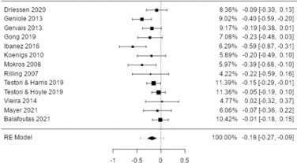

Fig. 2. Meta-analytic effect sizes (Pearson’s r) for correlations between psychopathy total scores and cooperation, aggregated across all paradigms. Note. Error bars indicate 95% Confidence Intervals.

### 3.2. Offer size

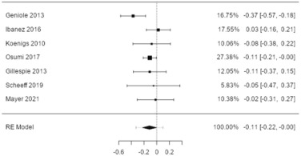

Fig. 3. Meta-analytic effect sizes (Pearson’s r) for correlations between psychopathy scores and offers aggregated across all paradigms**,** Note. Error bars indicate 95% Confidence Intervals.

### 3.3. Total gain

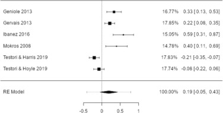

Fig. 4. Meta-analytic effect sizes (Pearson’s r) for correlations between psychopathy scores and total gain aggregated across all paradigms**,** Note. Error bars indicate 95% Confidence Intervals.

## 4. Discussion

The present meta-analysis shows that increased levels of psychopathic traits are associated with less cooperative behavior and lower offers across social economic decision-making paradigms. Moreover, our findings suggest that individuals with high levels of psychopathic traits ignore the potential retaliative acts of opponents in their behavioral choices. Finally, these individuals obtain higher gains in games where opponents lack the option to retaliate, compared to reciprocal games. In the following sections we will discuss these findings in more detail.

### 4.1. Cooperation

The results indicated that increasing levels of psychopathic traits co-occurred with reduced cooperation across social economic decision-making contexts. The manifestation of uncooperative behavior varies across paradigms. In a Trust Game, for instance, defection takes the form of lower reciprocal actions when offered the opportunity to reward the investor for their investment. In contrast, defection in an Ultimatum or Dictator Game relates to the individual’s posed offers. The finding that individuals with high levels of psychopathic traits are inclined to behave less cooperative across a range of social economic decision-making contexts aligns with our primary hypothesis and emphasizes the interpersonal component of psychopathic traits. More generally, the finding supports contemporary theories of psychopathy which postulate that psychopathy encompasses interpersonal deficits and antisocial tendencies. Yet, these theories insinuate different motivations for reduced cooperative behavior.

Prevailing theories of psychopathy tend to emphasize affective deficits. One prominent account is Lykken’s low-fear hypothesis, which suggests that psychopathy is underpinned by an impairment of fear processing (Lykken, 1957, Lykken, 1995). Psychopathic individuals are thought to experience the emotion of fear to a lesser extent. Hypothesized mechanisms underlying this lack of fear are deficits in passive avoidance learning (i.e., learning to avoid an aversive stimulus by inhibiting a previously punished response) and fear conditioning (i.e., learning to associate a particular neutral stimulus with an aversive stimulus) (Birbaumer et al., 2005; Blair et al., 2004; Oba et al., 2019; Veit et al., 2013). Punishing responses are inherent to learning appropriate behavior in social situations, and many parenting methods rely on punishment of undesirable behaviors. Consequently, individuals scoring high on psychopathic traits may be more inclined to engage in deviant behaviors due to the lack of fear associated with undesirable outcomes. Since noncooperative behavior tends to yield the highest reward for the individual, there are few reasons not to act in socially deviant manners if fear of social or monetary punishment is disregarded.

In contrast to previously discussed emotion-focused theories, attention-based models suggest broad and nonspecific attention deficits to underpin psychopathy. The Response Modulation Hypothesis (RMH; Gorenstein and Newman, 1980; Newman and Baskin-Sommers, 2016) concerns individuals’ ability to modulate a dominant response set in the presence of nondominant response cues. Psychopathic individuals are thought to focus on immediate, motivationally salient cues while disregarding peripheral information. The attentional bottleneck model (Baskin-Sommers and Brazil, 2022) elaborates on the underlying mechanism, suggesting an exaggerated attention bottleneck that restricts parallel processing of peripheral cues. Such an overactive attention bottleneck in psychopathy filters out too much information and forces serial processing instead. Evidence in favor of the attentional bottleneck comes from studies investigating information processing in dual-task conditions. These studies showed that psychopathy-related deficits are most apparent in tasks that required participants to learn and track multiple sets or types of contingencies (e.g., Von Borries et al., 2010; Newman and Kosson, 1986). It has been demonstrated that increasing levels of psychopathic traits are associated with reduced interference to response incongruent information when this information is presented outside the focus of attention (Scheeff et al., 2021, Zeier and Newman, 2013). Regarding cooperation, the attention-based models of psychopathy suggest that a disregard of contextual information, as a consequence of an exaggerated attention bottleneck, explains the negative relationship between psychopathic traits and cooperation. For instance, when in pursuit of monetary reward, individuals with elevated levels of psychopathy may be less likely to incorporate affective cues of the social interaction in their decision-making. This is limited to instances where cooperation cues remain outside the central focus of attention. As such, one may expect these individuals to consider contextual social cues when amply encouraged to do so.

Taken together, conceptualizations of psychopathy tend to converge in their predictions on cooperative behavior, while their proposed underlying motivations diverge. To effectively differentiate between said theories, we need to address the boundary conditions of the suggested deficits. For instance, absence of fear-related deficits when fear-related cues are the focus of attention challenge contemporary affective theories of psychopathy (Lykken, 1995, Newman et al., 2010). It is important to consider the situational specificity of dysfunctions associated with psychopathy, something that has become clear from researchers extending upon overly simplistic social economic decision-making studies in recent years and considering variables that go beyond the binary cooperation-defection distinction (e.g., Driessen et al., 2021; Gong et al., 2019; Osumi and Ohira, 2017; Testori et al., 2019). Throughout the following paragraph we will address the moderating variables of interest to the relationship of psychopathic traits and cooperation.

Our findings indicated that the negative relationship between psychopathic traits and cooperation is not moderated by any of the included moderators. Whereas scholars have suggested that the behavior that is associated with F1 and F2 subtypes may be driven by different motivations (Karpman, 1941, Mealey, 1995), our findings indicated no moderating effect of factor on the observed association of psychopathy and cooperation. Our analysis of the factor structure is limited as we aggregated findings of studies using a wide range of psychopathy measures, only some of which strictly adhere to the F1/F2 distinction. The PPI F1, for instance, incorporates adaptive aspects. whereas F1 of the PCL-R is strictly limited to maladaptive characteristics of the disorder (Benning et al., 2003, Miller and Lynam, 2012). While findings seem to indicate that primary and secondary psychopathy are associated with the F1/F2 distinction (Levenson et al., 1995), future studies may analyze a more homogenous sample of psychopathy measures or look for an interaction between the psychopathy scales and their factor structures (Malterer et al., 2010, Poythress et al., 2010).

Two additional moderators pertain to the measurements used to assess psychopathic trait levels. The clinical utility and factor structure of the different psychopathy measures have been compared extensively (Cooke and Michie, 2001, Drislane et al., 2014, Flórez et al., 2020, Hare, 1985, Hare, 1996, Hare, 2003; Hare & Neumann, 2006; Tsang et al., 2018), but there is little insight as to the relevance of these differences for cooperative behavior. Our findings suggest that differences in psychopathy measures do not differentially account for the relationship between psychopathy and cooperation, and conflicts with the limited evidence of psychopathy measures contributing to differences in findings of cooperation in psychopathic individuals (Rilling et al., 2007). We observed the same null effect for the moderator splitting psychopathy scales into those neglecting and those incorporating positive aspects of psychopathy. This finding goes against the notion that scales incorporating positive aspects of psychopathy may do better at accounting for positive behavioral outcomes, such as cooperation.

At last, our analysis revealed no significant differences in the association of psychopathic traits and cooperative behavior in the Ultimatum and the Dictator game. The non-significant moderating effect of game suggests that individuals with elevated psychopathic traits tend to disregard important differences between paradigms in their pursuit to obtain valuable outcomes. Individuals low on psychopathic traits are thought to incorporate the knowledge of potential retaliative actions in their decision-making. As such, paradigms where participants may be punished motivate cooperative behavior. The finding that individuals with elevated psychopathic traits tend not to incorporate that knowledge can be explained by affective and cognitive accounts of psychopathy. The former may argue that a lower experience of fear alters motivational contingencies in individuals with elevated psychopathic traits (Lykken, 1995). Attentional accounts, on the other hand, account for the finding by suggesting that peripheral cues, in this case the affective reactions of the other agent, tend to be disregarded by individuals high on psychopathic traits (Hamilton et al., 2015).

### 4.2. Offer size

Results for the analysis of offer sizes in social economic decision-making games indicate a significant negative association with psychopathic traits. As such, individuals with elevated levels of psychopathy tend to propose lower offers. It should be noted that results from the file drawer analyses give reason to question the robustness of the effect and suggest that the effect may be susceptible to publication bias. Therefore, we are cautious with drawing firm conclusions. Our observation aligns with the extant literature documenting violations of social norms and reduced concern for the welfare of others in individuals with psychopathic tendencies (Chang et al., 2011, Gillespie et al., 2013, Hare, 1996, Hare, 1998, Harpur et al., 1989, Mokros et al., 2008). Interestingly, some studies suggested that individuals with high levels of psychopathic traits have a different sense of fairness and proposed that this could explain antisocial choices in social economic games (e.g., Driessen et al., 2021, Osumi and Ohira, 2010). This notion is supported by findings showing that individuals with elevated levels of psychopathic traits not only pose lower offers but also accepted more unfair offers and perceived unfair offers as being less unfair (Osumi and Ohira, 2010, Vieira et al., 2014). A first study that investigated the role of fairness considerations in social economic decision-making and compared it with potential other motivations combined a new social economic game with computational modeling and showed that psychopathy was indeed negatively associated with inequity-aversion (Driessen et al., 2021). Competing theories have been suggested as to why psychopathic traits are associated with reduced cooperative and general moral behavior (Chang et al., 2011, Driessen et al., 2021, Glenn et al., 2009, Gong et al., 2019, van Baar et al., 2020). While our present results fail to differentiate between guilt-aversion and inequity-aversion motives of offering behavior, recent methodological advancements have made it possible to differentiate between distinct moral decision strategies by combining new experimental tasks with computational modeling (Driessen et al., 2021, Gong et al., 2019, van Baar et al., 2019). The approach of computational modelling to the behavioral strategy proves a promising way of discerning between different strategies and obtaining more detailed insight into the motivations for cooperative or defective behavior.

### 4.3. Total gain

The results for the analysis of total gain in social economic decision-making indicated that psychopathic traits are unrelated to the total gain obtained in social economic decision-making games. Yet, our findings lack scope to draw comprehensive conclusions about the adaptive value of particular psychopathic traits (Bronchain et al., 2020, Meloy et al., 2018). Whereas our findings preclude conclusions about the sensitivity to reward itself, they are relevant to the efficacy in achieving desired gains. Arguably, one would expect increased effort in obtaining rewards that are highly valued. However, this does not necessarily translate to increased efficacy in obtaining said rewards, and our findings indicate that psychopathic individuals are not more successful at achieving monetary rewards (Blair, 2008; Buckholtz et al., 2010; Cleckley, 1941; Everitt et al., 2008; Fowles, 1980; Gorenstein and Newman, 1980; Lykken, 1957; Pujara et al., 2013). However, findings of the moderator analyses demonstrated that the type of game significantly moderated the effect of psychopathy on total gain. More specifically, individuals with elevated levels of psychopathic traits appeared to obtain a higher outcome in games that exclude the possibility of an opponent retaliating on the current or later trials. This is in line with our other finding showing that psychopathic traits are linked to lower offers across all games and provides further insight into the efficacy of such a strategy. Posing a low offer in the Dictator game results in a higher gain, while posing a low offer in the Ultimatum or Prisoner Game increases the risk of retaliation by the opponent and therefore potentially results in a lower gain. Thus, the significant moderating effect of game on the relation between psychopathy and total gain could be explained by the risk of retaliation in the social economic decision-making games. Based on the current findings we could not conclude whether individuals scoring low on psychopathic traits, or community-dwelling individuals in general, do not adapt at all or do adapt to a lesser extent.

The question whether psychopathy scales that incorporate positive aspects of the personality construct are better at accounting for positive outcomes, such as cooperation, was addressed in the moderation analysis. Our findings indicate no significant moderation effect of scales including or discarding positive aspects of psychopathy. However, it is worth noting, that we did observe a negative trend in said moderation. Nevertheless, the moderation did not reach significance, and we conclude that although some scales do incorporate positive aspects of psychopathy, they demonstrate no greater utility at predicting the total gain of psychopathic individuals.

Finally, we should note that the proportion of the variance in study estimates concerning total gain that is due to heterogeneity was high (Deeks, 2011). Accordingly, any interpretation of these results should be taken with care. Several explanations can be devised for this observation. It is possible that total gain in social economic decision-making games vary greatly across the studies. This seems plausible, given that we observe many differences in social economic decision-making paradigms, some of which are more generous in the allocation of rewards, whereas others are more restricted. Alternatively, it is possible that results are biased, and the resulting conclusions are flawed. Whereas we consider the former to be more plausible, the following conclusions should be taken with care and further research into the amount of total gain in social economic decision-making games is warranted (Deeks, 2011).

Overall, the pattern of results indicated that individuals scoring high on psychopathy are less likely to engage in cooperative behavior and have the tendency to pose low offers regardless of the risk of retaliation by the opponent. The latter finding suggests that these individuals fail to consider potential retaliative acts of others. In line with these findings, while there was no overall effect of psychopathy on the total gain, we did find that individuals scoring high on psychopathy are more likely to end up with large gains in games where opponents do not get a chance to retaliate. Taken together, the results demonstrate that the social economic behavior of psychopaths is a result of many interacting factors.

### 4.4. Quality assessment and limitations

Note, however, that there is substantial heterogeneity amid study findings and the degree to which cooperative behavior can be explained by psychopathic traits is inconsistent between experiments. Another limitation follows from the relatively small set of studies on social economic decision-making of psychopathic individuals. More research is required to separate the effects of psychopathy across different economic games, as well as investigate differences in social economic decision making in clinical and pre-clinical data. These nuanced effects are of great interest and future research may utilize recent methodological developments outlined in the present review.

### 4.5. General summary and discussion

Marked interpersonal deficits are considered fundamental to the construct psychopathy. Several studies have documented the social behavior in relation to psychopathic traits across a variety of social economic decision-making games and aimed to obtain insight into the drives and motivations of social behavior of individuals who demonstrate elevated psychopathic traits. The present meta-analysis offers the first comprehensive review of psychopaths’ choice behavior in social economic games. In doing so, we were able to incorporate a larger variety of factors that are relevant to the social economic choices of individuals and allow for more meaningful assessments of behavior and behavioral motives. Our findings demonstrated that elevated psychopathic traits are associated with less cooperative behavior and lower offers across social economic paradigms. Both effects are reflected in our contemporary understanding of psychopathy as being characterized by marked social deficits and disregard for others. Moreover, our findings suggest that psychopathic individuals ignore the potential retaliative acts of opponents in their behavioral choices challenge. This might be explained by their engagement in risky decision-making to obtain a high reward. At last, our findings concerning the gains in social economic decision-making games indicate that, overall, individuals with elevated psychopathic traits are no better at obtaining them. However, when we make a distinction based on the type of game, our findings demonstrate that individuals scoring high on psychopathy obtain higher gains in games where opponents lack the option to retaliate. Taken together, we could argue that the risky and antisocial strategy adopted by individuals scoring high on psychopathic traits is successful in situations where one has full control over the outcome, but not in situations where reciprocity plays a role. Thus, as psychopathic traits turn out to benefit the level of success only in certain situations, our findings conflict with the idea of *successful psychopathy* (Lasko and Chester, 2021, Palmen et al., 2018, Persson and Lilienfeld, 2019)*.* Our findings summarize existing research on social economic decision-making in psychopathy and supports the idea that personality traits have substantial predictive power in the field of economics and can help us better understand economic behavior across strategic contexts (Borghans et al., 2008, Engelmann et al., 2019). It further demonstrates directions for future research, which should devote attention to more refined behavioral drives and consider the complexity of social economic environments.

Competing theories have been suggested as to why psychopathic traits are associated with reduced cooperative behavior in social economic contexts (Chang et al., 2011, Driessen et al., 2021, Glenn et al., 2009, Gong et al., 2019, van Baar et al., 2020). One prominent line of thinking incorporates the idea that people typically generate beliefs about what others expect from us and suggests that people are motivated to cooperate to avoid feelings of guilt for not living up to another’s expectations. Studies showed that psychopathy is negatively associated with such a guilt-averse motivation (Blair et al., 2006, Cleckley, 1941, Gong et al., 2019, Seara-Cardoso et al., 2016). An alternative theory proposes that fairness considerations motivate cooperative behavior in humans. According to this theory, people value the equity in outcome between themselves and another person and are often willing to sacrifice some of their own payout to ensure more equitable outcomes with others. Studies on the role of fairness considerations during social economic decision-making in psychopathy have yielded mixed results. Until recently, there were no direct comparisons between these two hypotheses as traditional social economic decision-making paradigms do not allow us to differentiate between guilt and fairness considerations. That is, the two motivations typically result in similar behavioral patterns in such paradigms. However, there have been some promising developments in this direction and studies have gone beyond the general characteristics of social environments to gather insight into the drives and motives of cooperative behavior as a function of psychopathic traits (Driessen et al., 2021, Gervais et al., 2013, Gong et al., 2019, van Baar et al., 2019). Recent methodological advancements have made it possible to differentiate between distinct moral decision strategies by combining new experimental tasks with computational modeling (Driessen et al., 2021, Gong et al., 2019, van Baar et al., 2019). The approach of computational modelling to the behavioral strategy proves a promising way of discerning between different strategies and obtaining more detailed insight into the motivations for cooperative or defective behavior.

Following the same trend of increasing the specificity at which different strategies can be detected, different approaches have been utilized to discern reward learning from social decision-making (e.g., Martins et al., 2022; Sul et al., 2015). Sul and colleagues (2015) developed a new instrumental learning task (i.e., prosocial learning task) that helps disentangle prosocial from self-oriented learning. By splitting participants in conditions where obtaining points would benefit the self or another individual, the researchers were able to investigate individual differences in prosociality specifically. Several studies have demonstrated that self- and other-regarding choices are critically involved in determining prosocial behavior (Cutler et al., 2021, Lockwood et al., 2017, Piva et al., 2019, Sul et al., 2015). These findings emphasize the importance of adopting more rigorous scientific methods in order to better understand human decision-making.

It is important to acknowledge potential limitations when considering the results of the present review. The studies included differed in samples (forensic vs. non-forensic), conceptualization of the construct of psychopathy, and used social economic decision-making games. In general, social economic decision-making games are designed to resemble real-life behavior in social situations. Therefore, it is essential that individuals believe in the legitimacy of these interactions and attach value to the potential outcomes, both social and economic. Hypothetical scenarios lack the consequences for actual social and economic outcomes that real social economic decisions have. Therefore, an expected increase in social desirability may cause an inflation in effect sizes of studies using hypothetical rather than behavior-contingent designs (Moshagen et al., 2011, Thielmann et al., 2016). Games during which participants are aware that their decisions will not influence their monetary payout encourage a shift toward more cooperative behavior as it comes at no actual cost to the individual. This effect is even stronger for selfish individuals (e.g., Hilbig et al., 2015). Therefore, under the assumption that psychopathic individuals tend to cooperate less across social economic decision-making games, it may be reasonable to assume that hypothetical games diminish the negative association and lead to a decline in observed effect sizes. The same is true for studies where participants are not made aware of the hypothetical nature of the task. The extent to which experimenters manage to convince participants of the legitimacy of the social economic interaction may similarly affect the willingness to cooperate. Nevertheless, Thielmann et al. (2020) concluded that perception does not confound the results on personality and prosocial behavior, reporting merely a small effect of deception on study outcomes. Accordingly, this limitation does not necessarily warrant concern, considering that a small minority of participants was aware of the hypothetical nature.

### 4.6. Conclusion

The current study presents meta-analytical findings concerning the relationship of psychopathic traits and social economic decision-making. The results show that psychopathy is associated with reduced cooperative behavior across social economic decision-making paradigms, while such behavior leads to high gains only in situations that do not require reciprocal interactions. While these findings improve our understanding of how variations in psychopathy scores are linked to the ability to adapt to task characteristics, we also emphasize the need for studies that go beyond the general characteristics of social environments to gather insight into the underlying motivations of cooperative behavior as a function of psychopathic traits.

## Funding sources

This research did not receive any specific grant from funding agencies in the public, commercial, or not-for-profit sectors.

## Research data

The research data used for our meta-analyses are available on the Open Science Framework (https://osf.io/4hrk3/). Raw respondent data of the individual publications are not available but may be acquired from the respective researchers.

## Declarations of interest

None

## Appendix A. Supplementary material

[Download : Download Word document (135KB)](https://ars.els-cdn.com/content/image/1-s2.0-S0149763422004559-mmc1.docx)

Supplementary material

.

## Data Availability

The research data used for our meta-analyses are publicly available. Raw respondent data of the individual publications are not available and may be acquired from the respective researchers.

## References

**Aharoni et al., 2011**

E. Aharoni, O. Antonenko, K.A. Kiehl

**Disparities in the moral intuitions of criminal offenders: The role of psychopathy**

J. Res. Personal., 45 (3) (2011), pp. 322-327, 10.1016/j.jrp.2011.02.005

[Article](https://www.sciencedirect.com/science/article/pii/S0092656611000298)[Download PDF](https://www.sciencedirect.com/science/article/pii/S0092656611000298/pdfft?md5=9a14ae6dae7663c5e2fc0513fad9ba09&pid=1-s2.0-S0092656611000298-main.pdf)[View Record in Scopus](https://www.scopus.com/inward/record.url?eid=2-s2.0-79955479733&partnerID=10&rel=R3.0.0)Google Scholar

**Andreoni and Petrie, 2004**

J. Andreoni, R. Petrie

**Public goods experiments without confidentiality: a glimpse into fund-raising**

J. Public Econ., 88 (7–8) (2004), pp. 1605-1623, 10.1016/S0047-2727(03)00040-9

[Article](https://www.sciencedirect.com/science/article/pii/S0047272703000409)[Download PDF](https://www.sciencedirect.com/science/article/pii/S0047272703000409/pdfft?md5=f89b83e4dae87ef9c3acfbda63fdb21e&pid=1-s2.0-S0047272703000409-main.pdf)[View Record in Scopus](https://www.scopus.com/inward/record.url?eid=2-s2.0-0347129550&partnerID=10&rel=R3.0.0)[Google Scholar](https://scholar.google.com/scholar_lookup?title=Public%20goods%20experiments%20without%20confidentiality%3A%20a%20glimpse%20into%20fund-raising&publication_year=2004&author=J.%20Andreoni&author=R.%20Petrie)

**Balafoutas et al., 2021**

L. Balafoutas, A. García-Gallego, N. Georgantzis, T. Jaber-Lopez, E. Mitrokostas

**Psychopathy and economic behavior among prison inmates: An experiment**

Front. Psychol. (2021), p. 12, 10.3389/FPSYG.2021.732184/FULL

Google Scholar

**Baskin-Sommers and Brazil, 2022**

A.R. Baskin-Sommers, I.A. Brazil

**The importance of an exaggerated attention bottleneck for understanding psychopathy**

Trends Cogn. Sci., 26 (4) (2022), pp. 325-336, 10.1016/j.tics.2022.01.001

[Article](https://www.sciencedirect.com/science/article/pii/S136466132200016X)[Download PDF](https://www.sciencedirect.com/science/article/pii/S136466132200016X/pdfft?md5=189deae6826fcb8108cbb52e1b2306f0&pid=1-s2.0-S136466132200016X-main.pdf)[View Record in Scopus](https://www.scopus.com/inward/record.url?eid=2-s2.0-85123893487&partnerID=10&rel=R3.0.0)Google Scholar

**Baskin-Sommers et al., 2011**

A.R. Baskin-Sommers, J.J. Curtin, J.P. Newman

**Specifying the attentional selection that moderates the fearlessness of psychopathic offenders**

Psychol. Sci., 22 (2) (2011), pp. 226-234, 10.1177/0956797610396227

[View Record in Scopus](https://www.scopus.com/inward/record.url?eid=2-s2.0-79952060169&partnerID=10&rel=R3.0.0)Google Scholar

**Baumeister et al., 1994**

R.F. Baumeister, A.M. Stillwell, T.F. Heatherton

**Guilt: An interpersonal approach**

Psychol. Bull., 115 (2) (1994), pp. 243-267, 10.1037/0033-2909.115.2.243

[View Record in Scopus](https://www.scopus.com/inward/record.url?eid=2-s2.0-0028390399&partnerID=10&rel=R3.0.0)[Google Scholar](https://scholar.google.com/scholar_lookup?title=Guilt%3A%20An%20interpersonal%20approach&publication_year=1994&author=R.F.%20Baumeister&author=A.M.%20Stillwell&author=T.F.%20Heatherton)

**Benning et al., 2003**

S.D. Benning, C.J. Patrick, B.M. Hicks, D.M. Blonigen, R.F. Krueger

**Factor structure of the Psychopathic Personality Inventory: Validity and implications for clinical assessment**

Psychol. Assess., 15 (3) (2003), pp. 340-350, 10.1037/1040-3590.15.3.340

[View Record in Scopus](https://www.scopus.com/inward/record.url?eid=2-s2.0-0142116289&partnerID=10&rel=R3.0.0)Google Scholar

**Berg et al., 1995**

J. Berg, J. Dickhaut, K. McCabe

**Trust, reciprocity, and social history**

Games Econ. Behav., 10 (1) (1995), pp. 122-142, 10.1006/game.1995.1027

[Article](https://www.sciencedirect.com/science/article/pii/S0899825685710275)[Download PDF](https://www.sciencedirect.com/science/article/pii/S0899825685710275/pdf?md5=cae813e95147444d8ddadaf9babfbca8&pid=1-s2.0-S0899825685710275-main.pdf)[Google Scholar](https://scholar.google.com/scholar_lookup?title=Trust%2C%20reciprocity%2C%20and%20social%20history&publication_year=1995&author=J.%20Berg&author=J.%20Dickhaut&author=K.%20McCabe)

**Berg et al., 2013**

J.M. Berg, S.F. Smith, A.L. Watts, R. Ammirati, S.E. Green, S.O. Lilienfeld

**Misconceptions regarding psychopathic personality: Implications for clinical practice and research**

Neuropsychiatry, 3 (1) (2013), pp. 63-74, 10.2217/npy.12.69

[View Record in Scopus](https://www.scopus.com/inward/record.url?eid=2-s2.0-84874032837&partnerID=10&rel=R3.0.0)Google Scholar

**Birbaumer et al., 2005**

N. Birbaumer, R. Veit, M. Lotze, M. Erb, C. Hermann, W. Grodd, H. Flor

**Deficient fear conditioning in psychopathy**

Arch. Gen. Psychiatry, 62 (7) (2005), pp. 799-805, 10.1001/archpsyc.62.7.799

[View Record in Scopus](https://www.scopus.com/inward/record.url?eid=2-s2.0-21744446437&partnerID=10&rel=R3.0.0)Google Scholar

**Blackburn, 1988**

R. Blackburn

**On moral judgements and personality disorders**

Br. J. Psychiatry, 153 (4) (1988), pp. 505-512, 10.1192/bjp.153.4.505

[View Record in Scopus](https://www.scopus.com/inward/record.url?eid=2-s2.0-0023735547&partnerID=10&rel=R3.0.0)[Google Scholar](https://scholar.google.com/scholar_lookup?title=On%20moral%20judgements%20and%20personality%20disorders&publication_year=1988&author=R.%20Blackburn)

**Blair et al., 2006**

K.S. Blair, J. Morton, A. Leonard, R.J.R. Blair

**Impaired decision-making on the basis of both reward and punishment information in individuals with psychopathy**

Personal. Individ. Differ., 41 (1) (2006), pp. 155-165, 10.1016/j.paid.2005.11.031

[Article](https://www.sciencedirect.com/science/article/pii/S0191886906000547)[Download PDF](https://www.sciencedirect.com/science/article/pii/S0191886906000547/pdfft?md5=3150523d7f92e21fc53480bffdfc6f55&pid=1-s2.0-S0191886906000547-main.pdf)[View Record in Scopus](https://www.scopus.com/inward/record.url?eid=2-s2.0-33646471978&partnerID=10&rel=R3.0.0)Google Scholar

**Blair, 2007**

R.J.R. Blair

**The amygdala and ventromedial prefrontal cortex in morality and psychopathy**

Trends Cogn. Sci., 11 (9) (2007), pp. 387-392, 10.1016/j.tics.2007.07.003

[Article](https://www.sciencedirect.com/science/article/pii/S136466130700191X)[Download PDF](https://www.sciencedirect.com/science/article/pii/S136466130700191X/pdfft?md5=17af540683528ef41cb205aae43dfdb0&pid=1-s2.0-S136466130700191X-main.pdf)[View Record in Scopus](https://www.scopus.com/inward/record.url?eid=2-s2.0-34548265174&partnerID=10&rel=R3.0.0)[Google Scholar](https://scholar.google.com/scholar_lookup?title=The%20amygdala%20and%20ventromedial%20prefrontal%20cortex%20in%20morality%20and%20psychopathy&publication_year=2007&author=R.J.R.%20Blair)

**Blair, 2008**

R.J.R. Blair

**The amygdala and ventromedial prefrontal cortex: Functional contributions and dysfunction in psychopathy**

Philos. Trans. R. Soc. B: Biol. Sci., 363 (1503) (2008), pp. 2557-2565, 10.1098/rstb.2008.0027

[View Record in Scopus](https://www.scopus.com/inward/record.url?eid=2-s2.0-46249134005&partnerID=10&rel=R3.0.0)Google Scholar

**Blair, 2013a**

R.J.R. Blair

**Psychopathy: cognitive and neural dysfunction**

Dialog-. Clin. Neurosci., 15 (2) (2013), pp. 181-190

[View Record in Scopus](https://www.scopus.com/inward/record.url?eid=2-s2.0-84888057971&partnerID=10&rel=R3.0.0)[Google Scholar](https://scholar.google.com/scholar_lookup?title=Psychopathy%3A%20cognitive%20and%20neural%20dysfunction&publication_year=2013&author=R.J.R.%20Blair)

**Blair, 2013b**

R.J.R. Blair

**The neurobiology of psychopathic traits in youths**

Nat. Rev. Neurosci., 14 (11) (2013), pp. 786-799, 10.1038/nrn3577

[Google Scholar](https://scholar.google.com/scholar_lookup?title=The%20neurobiology%20of%20psychopathic%20traits%20in%20youths&publication_year=2013&author=R.J.R.%20Blair)

**Blair et al., 2004**

R.J.R. Blair, D.G.V. Mitchell, A. Leonard, S. Budhani, K.S. Peschardt, C. Newman

**Passive avoidance learning in individuals with psychopathy: Modulation by reward but not by punishment**

Personal. Individ. Differ., 37 (6) (2004), pp. 1179-1192, 10.1016/j.paid.2003.12.001

[Article](https://www.sciencedirect.com/science/article/pii/S0191886903004586)[Download PDF](https://www.sciencedirect.com/science/article/pii/S0191886903004586/pdfft?md5=6654c2017bb4db7e7deb5b8ebbadae1c&pid=1-s2.0-S0191886903004586-main.pdf)[View Record in Scopus](https://www.scopus.com/inward/record.url?eid=2-s2.0-4544254399&partnerID=10&rel=R3.0.0)Google Scholar

**Bolton and Zwick, 1995**

G.E. Bolton, R.R. Zwick

**Anonymity versus punishment in ultimatum bargaining**

Games Econ. Behav., 10 (10) (1995), pp. 95-121, 10.1006/game.1995.1026

[Article](https://www.sciencedirect.com/science/article/pii/S0899825685710263)[Download PDF](https://www.sciencedirect.com/science/article/pii/S0899825685710263/pdf?md5=68f174dada3fb7ea82fdeab4cbba05f0&pid=1-s2.0-S0899825685710263-main.pdf)[View Record in Scopus](https://www.scopus.com/inward/record.url?eid=2-s2.0-0002194670&partnerID=10&rel=R3.0.0)[Google Scholar](https://scholar.google.com/scholar_lookup?title=Anonymity%20versus%20punishment%20in%20ultimatum%20bargaining&publication_year=1995&author=G.E.%20Bolton&author=R.R.%20Zwick)

**Bolton and Ockenfels, 2000**

G.E. Bolton, A. Ockenfels

**ERC: a theory of equity, reciprocity, and competition**

Am. Econ. Rev., 90 (1) (2000), pp. 166-193

[CrossRef](https://doi.org/10.1257/aer.90.1.166)[View Record in Scopus](https://www.scopus.com/inward/record.url?eid=2-s2.0-0000885425&partnerID=10&rel=R3.0.0)[Google Scholar](https://scholar.google.com/scholar_lookup?title=ERC%3A%20a%20theory%20of%20equity%2C%20reciprocity%2C%20and%20competition&publication_year=2000&author=G.E.%20Bolton&author=A.%20Ockenfels)

**Borghans et al., 2008**

Borghans, L., Duckworth, A.L., Heckmann, J.J., & ter Weel, B. (2008). The economics and psychology of personality traits. *NBER Working Paper*. [〈http://jenni.uchicago.edu/econ-psych-traits/〉](http://jenni.uchicago.edu/econ-psych-traits/),

Google Scholar

**Bowles and Gintis, 2005**

S. Bowles, H. Gintis

**Can self-interest explain cooperation**

Evolut. Inst. Econ. Rev., 2 (1) (2005), pp. 21-41, 10.14441/eier.2.21

[View Record in Scopus](https://www.scopus.com/inward/record.url?eid=2-s2.0-77950959568&partnerID=10&rel=R3.0.0)[Google Scholar](https://scholar.google.com/scholar_lookup?title=Can%20self-interest%20explain%20cooperation&publication_year=2005&author=S.%20Bowles&author=H.%20Gintis)

**Bowles and Gintis, 2011**

S. Bowles, H. Gintis

**Cooperative homo economicus**

A Cooperative Species: Human Reciprocity and Its Evolution, Princepton University Press, (2011), pp. 79-92

https://doi.org/https://doi-org.ru.idm.oclc.org/10.1515/9781400838837

[CrossRef](https://doi.org/10.1515/9781400838837.79)[Google Scholar](https://scholar.google.com/scholar_lookup?title=Cooperative%20homo%20economicus&publication_year=2011&author=S.%20Bowles&author=H.%20Gintis)

**Brazil and Cima, 2016**

I.A. Brazil, M. Cima

**Contemporary approaches to psychopathy**

The handbook of forensic psychopathology and treatment, Routledge, (2016), 10.4324/9781315637105-22

[Google Scholar](https://scholar.google.com/scholar_lookup?title=Contemporary%20approaches%20to%20psychopathy&publication_year=2016&author=I.A.%20Brazil&author=M.%20Cima)

**Brazil et al., 2011**

I.A. Brazil, R.B. Mars, B.H. Bulten, J.K. Buitelaar, R.J. Verkes, E.R.A. De Bruijn

**A neurophysiological dissociation between monitoring one’s own and others’ actions in psychopathy**

Biol. Psychiatry, 69 (7) (2011), pp. 693-699, 10.1016/j.biopsych.2010.11.013

[Article](https://www.sciencedirect.com/science/article/pii/S0006322310011960)[Download PDF](https://www.sciencedirect.com/science/article/pii/S0006322310011960/pdfft?md5=e6a8c4df060163f70eb99d1fa9dc0b4f&pid=1-s2.0-S0006322310011960-main.pdf)[View Record in Scopus](https://www.scopus.com/inward/record.url?eid=2-s2.0-79952575638&partnerID=10&rel=R3.0.0)[Google Scholar](https://scholar.google.com/scholar?q=A%20neurophysiological%20dissociation%20between%20monitoring%20ones%20own%20and%20others%20actions%20in%20psychopathy)

**Bronchain et al., 2020**

J. Bronchain, P. Raynal, H. Chabrol

**Heterogeneity of adaptive features among psychopathy variants**

Personal. Disord.: Theory, Res., Treat., 11 (1) (2020), pp. 63-68, 10.1037/per0000366

[View Record in Scopus](https://www.scopus.com/inward/record.url?eid=2-s2.0-85073101373&partnerID=10&rel=R3.0.0)[Google Scholar](https://scholar.google.com/scholar_lookup?title=Heterogeneity%20of%20adaptive%20features%20among%20psychopathy%20variants&publication_year=2020&author=J.%20Bronchain&author=P.%20Raynal&author=H.%20Chabrol)

**Brosnan, 2006**

S.F. Brosnan

**Nonhuman species’ reactions to inequity and their implications for fairness**

*2006 19:2*

Soc. Justice Res., 19 (2) (2006), pp. 153-185, 10.1007/s11211-006-0002-z

[View Record in Scopus](https://www.scopus.com/inward/record.url?eid=2-s2.0-33747883667&partnerID=10&rel=R3.0.0)[Google Scholar](https://scholar.google.com/scholar?q=Nonhuman%20species%20reactions%20to%20inequity%20and%20their%20implications%20for%20fairness)

**Brown and Vincent, 2008**

J.S. Brown, T.L. Vincent

**Evolution of cooperation with shared costs and benefits**

Proc. R. Soc. B: Biol. Sci., 275 (1646) (2008), pp. 1985-1994, 10.1098/rspb.2007.1685

[View Record in Scopus](https://www.scopus.com/inward/record.url?eid=2-s2.0-47249122891&partnerID=10&rel=R3.0.0)[Google Scholar](https://scholar.google.com/scholar_lookup?title=Evolution%20of%20cooperation%20with%20shared%20costs%20and%20benefits&publication_year=2008&author=J.S.%20Brown&author=T.L.%20Vincent)

**Brülhart and Usunier, 2012**

M. Brülhart, J.C. Usunier

**Does the trust game measure trust**

Econ. Lett., 115 (1) (2012), pp. 20-23, 10.1016/j.econlet.2011.11.039

[Article](https://www.sciencedirect.com/science/article/pii/S0165176511005040)[Download PDF](https://www.sciencedirect.com/science/article/pii/S0165176511005040/pdfft?md5=dd0855e48b7bb58f088a3072f25a8a8b&pid=1-s2.0-S0165176511005040-main.pdf)[View Record in Scopus](https://www.scopus.com/inward/record.url?eid=2-s2.0-84857551512&partnerID=10&rel=R3.0.0)[Google Scholar](https://scholar.google.com/scholar_lookup?title=Does%20the%20trust%20game%20measure%20trust&publication_year=2012&author=M.%20Br%C3%BClhart&author=J.C.%20Usunier)

**Buckholtz et al., 2010**

J.W. Buckholtz, M.T. Treadway, R.L. Cowan, N.D. Woodward, S.D. Benning, R. Li, M.S. Ansari, R.M. Baldwin, A.N. Schwartzman, E.S. Shelby, C.E. Smith, D. Cole, R.M. Kessler, D.H. Zald

**Mesolimbic dopamine reward system hypersensitivity in individuals with psychopathic traits**

Nat. Neurosci., 13 (4) (2010), pp. 419-421, 10.1038/nn.2510

[View Record in Scopus](https://www.scopus.com/inward/record.url?eid=2-s2.0-77950187595&partnerID=10&rel=R3.0.0)Google Scholar

**Cale and Lilienfeld, 2002**

E.M. Cale, S.O. Lilienfeld

**Sex differences in psychopathy and antisocial personality disorder: A review and integration**

Clin. Psychol. Rev., 22 (8) (2002), pp. 1179-1207, 10.1016/S0272-7358(01)00125-8

[Article](https://www.sciencedirect.com/science/article/pii/S0272735801001258)[Download PDF](https://www.sciencedirect.com/science/article/pii/S0272735801001258/pdfft?md5=c5a692badca9320f7216ace745291545&pid=1-s2.0-S0272735801001258-main.pdf)[View Record in Scopus](https://www.scopus.com/inward/record.url?eid=2-s2.0-0036837301&partnerID=10&rel=R3.0.0)Google Scholar

**Camerer et al., 2003**

C. Camerer, H. Teck, K. Chong

**Models of thinking, learning, and teaching in games**

Am. Econ. Rev., 93 (2) (2003), pp. 192-195, 10.1257/000282803321947038

[View Record in Scopus](https://www.scopus.com/inward/record.url?eid=2-s2.0-0038606302&partnerID=10&rel=R3.0.0)[Google Scholar](https://scholar.google.com/scholar_lookup?title=Models%20of%20thinking%2C%20learning%2C%20and%20teaching%20in%20games&publication_year=2003&author=C.%20Camerer&author=H.%20Teck&author=K.%20Chong)

**Capraro et al., 2014**

V. Capraro, C. Smyth, K. Mylona, G.A. Niblo

**Benevolent characteristics promote cooperative behaviour among humans**

PLoS ONE, 9 (8) (2014), 10.1371/journal.pone.0102881

Google Scholar

**Chang et al., 2011**

L.J. Chang, A. Smith, M. Dufwenberg, A.G. Sanfey

**Triangulating the neural, psychological, and economic bases of guilt aversion**

Neuron, 70 (3) (2011), pp. 560-572, 10.1016/j.neuron.2011.02.056

[Article](https://www.sciencedirect.com/science/article/pii/S0896627311002996)[Download PDF](https://www.sciencedirect.com/science/article/pii/S0896627311002996/pdfft?md5=abe49354a695165ae3115e7e3b496048&pid=1-s2.0-S0896627311002996-main.pdf)[View Record in Scopus](https://www.scopus.com/inward/record.url?eid=2-s2.0-79955657918&partnerID=10&rel=R3.0.0)Google Scholar

**Chatman et al., 1995**

J.A. Chatman, S.G. Barsade, D. Caldwell, B. Hermalin, C. McCusker, J. Polzer, B. Roberts, T. Tyler, E. Jehn, K. Mozier, M. Neale, B. Staw

**Personality, organizational culture, and cooperation: Evidence from a business simulation**

Adm. Sci. Q., 40 (1995), pp. 423-443

https://doi.org/0001-8392/95/4003-0423/$1.00.0

[CrossRef](https://doi.org/10.2307/2393792)Google Scholar

**Cleckley, 1941**

H.M. Cleckley

**The mask of sanity; An attempt to reinterpret the so-called psychopathic personality**

Mosby (1941)

[Google Scholar](https://scholar.google.com/scholar_lookup?title=The%20mask%20of%20sanity%3B%20An%20attempt%20to%20reinterpret%20the%20so-called%20psychopathic%20personality&publication_year=1941&author=H.M.%20Cleckley)

**Cohen, 1969**

J. Cohen

**Statistical power analysis for the behavioral sciences**

Routledge (1969), 10.4324/9780203771587

[Google Scholar](https://scholar.google.com/scholar_lookup?title=Statistical%20power%20analysis%20for%20the%20behavioral%20sciences&publication_year=1969&author=J.%20Cohen)

**Cohen, 1992**

J. Cohen

**Statistical power analysis**

Curr. Dir. Psychol. Sci., 1 (3) (1992), pp. 98-101, 10.1111/1467-8721.ep10768783

[Google Scholar](https://scholar.google.com/scholar_lookup?title=Statistical%20power%20analysis&publication_year=1992&author=J.%20Cohen)

**Cooke and Michie, 2001**

D.J. Cooke, C. Michie

**Refining the construct of psychopathy: Towards a hierarchical model**

Psychol. Assess., 13 (2) (2001), pp. 171-188, 10.1037/1040-3590.13.2.171

[View Record in Scopus](https://www.scopus.com/inward/record.url?eid=2-s2.0-0034976504&partnerID=10&rel=R3.0.0)[Google Scholar](https://scholar.google.com/scholar_lookup?title=Refining%20the%20construct%20of%20psychopathy%3A%20Towards%20a%20hierarchical%20model&publication_year=2001&author=D.J.%20Cooke&author=C.%20Michie)

**Cooper et al., 2009**

H. Cooper, L.V. Hedges, J.C. Valentine

**The handbook of research synthesis and meta-analysis**

Russell Sage Foundation (2009)

[Google Scholar](https://scholar.google.com/scholar_lookup?title=The%20handbook%20of%20research%20synthesis%20and%20meta-analysis&publication_year=2009&author=H.%20Cooper&author=L.V.%20Hedges&author=J.C.%20Valentine)

**Cowen and Sutter, 1999**

T. Cowen, D. Sutter

**The costs of cooperation**

Rev. Austrian Econ., 12 (2) (1999), pp. 161-173, 10.1023/A:1007864125523

[View Record in Scopus](https://www.scopus.com/inward/record.url?eid=2-s2.0-0011290975&partnerID=10&rel=R3.0.0)[Google Scholar](https://scholar.google.com/scholar_lookup?title=The%20costs%20of%20cooperation&publication_year=1999&author=T.%20Cowen&author=D.%20Sutter)

**Crowe et al., 2021**

M.L. Crowe, B.M. Weiss, C.E. Sleep, A.M. Harris, N.T. Carter, D.R. Lynam, J.D. Miller

**Fearless dominance/boldness is not strongly related to externalizing behaviors: an item response-based analysis**

Assessment, 28 (2) (2021), pp. 413-428, 10.1177/1073191120907959

[View Record in Scopus](https://www.scopus.com/inward/record.url?eid=2-s2.0-85081573221&partnerID=10&rel=R3.0.0)[Google Scholar](https://scholar.google.com/scholar?q=Fearless%20dominanceboldness%20is%20not%20strongly%20related%20to%20externalizing%20behaviors:%20an%20item%20response-based%20analysis)

**Curry, 2016**

O.S. Curry

**Morality as cooperation: a problem-centred approach**

Evolut. Psychol. (2016), pp. 27-51, 10.1007/978-3-319-19671-8_2

[View Record in Scopus](https://www.scopus.com/inward/record.url?eid=2-s2.0-84992585597&partnerID=10&rel=R3.0.0)[Google Scholar](https://scholar.google.com/scholar_lookup?title=Morality%20as%20cooperation%3A%20a%20problem-centred%20approach&publication_year=2016&author=O.S.%20Curry)

**Cutler et al., 2021**

J. Cutler, M.K. Wittmann, A. Abdurahman, L.D. Hargitai, D. Drew, M. Husain, P.L. Lockwood

**Ageing is associated with disrupted reinforcement learning whilst learning to help others is preserved**

Nat. Commun., 12 (1) (2021), pp. 1-13, 10.1038/s41467-021-24576-w

[View Record in Scopus](https://www.scopus.com/inward/record.url?eid=2-s2.0-85132749895&partnerID=10&rel=R3.0.0)Google Scholar

**Davis et al., 1993**

D.D. Davis, C.A. Holt, S.E. Económicos, J. Dec, N.J. Dec, D.D. Davis, C.A. Holt

**Experimental economics: methods, problems, and promise**

Estud. Econ., 8 (2) (1993), pp. 179-212

[CrossRef](https://doi.org/10.24201/ee.v8i2.288)Google Scholar

**De Vogel and Lancel, 2016**

V. De Vogel, M. Lancel

**Gender differences in the assessment and manifestation of psychopathy: results from a multicenter study in forensic psychiatric patients**

Int. J. Forensic Ment. Health, 15 (1) (2016), pp. 97-110, 10.1080/14999013.2016.1138173

[View Record in Scopus](https://www.scopus.com/inward/record.url?eid=2-s2.0-84961248166&partnerID=10&rel=R3.0.0)Google Scholar

**Deeks, 2011**

J.J. Deeks

**Chapter 9: analysing data and undertaking**

J.P.T. Higgins, S. Green (Eds.), Cochrane Handbook for Systematic Reviews of Interventions Version 5.1.0, John Wiley & Sons (2011), pp. 1-43

[Google Scholar](https://scholar.google.com/scholar_lookup?title=Chapter%209%3A%20analysing%20data%20and%20undertaking&publication_year=2011&author=J.J.%20Deeks)

**DeMatteo et al., 2006**

D. DeMatteo, K. Heilbrun, G. Marczyk

**An empirical investigation of psychopathy in a noninstitutionalized and noncriminal sample**

Behav. Sci. Law, 24 (2) (2006), pp. 133-146, 10.1002/bsl.667

[View Record in Scopus](https://www.scopus.com/inward/record.url?eid=2-s2.0-33646265752&partnerID=10&rel=R3.0.0)Google Scholar

**Diekmann and Lindenberg, 2015**

A. Diekmann, S. Lindenberg

**Cooperation: Sociological aspects**

International Encyclopedia of the Social & Behavioral Sciences (*Second edition*.,), Elsevier Inc, (2015), pp. 862-866, 10.1016/B978-0-08-097086-8.32031-1

[Article](https://www.sciencedirect.com/science/article/pii/B9780080970868320311)[Download PDF](https://www.sciencedirect.com/science/article/pii/B9780080970868320311/pdfft?md5=cc3c86af259ffcd88ae5e4276660ce08&pid=3-s2.0-B9780080970868320311-main.pdf)[View Record in Scopus](https://www.scopus.com/inward/record.url?eid=2-s2.0-85043431286&partnerID=10&rel=R3.0.0)[Google Scholar](https://scholar.google.com/scholar_lookup?title=Cooperation%3A%20Sociological%20aspects&publication_year=2015&author=A.%20Diekmann&author=S.%20Lindenberg)

**Driessen et al., 2021**

J.M.A. Driessen, J.M. van Baar, A.G. Sanfey, J.C. Glennon, I.A. Brazil

**Moral strategies and psychopathic traits**

J. Abnorm. Psychol., 130 (5) (2021), pp. 550-561, 10.1037/ABN0000675

[View Record in Scopus](https://www.scopus.com/inward/record.url?eid=2-s2.0-85117623508&partnerID=10&rel=R3.0.0)Google Scholar

**Drislane et al., 2014**

L.E. Drislane, C.J. Patrick, G. Arsal

**Clarifying the content coverage of differing psychopathy inventories through reference to the triarchic psychopathy measure**

Psychol. Assess., 26 (2) (2014), pp. 350-362, 10.1037/a0035152

[View Record in Scopus](https://www.scopus.com/inward/record.url?eid=2-s2.0-84901832019&partnerID=10&rel=R3.0.0)Google Scholar

**Efferson and Glenn, 2018**

L.M. Efferson, A.L. Glenn

**Examining gender differences in the correlates of psychopathy: a systematic review of emotional, cognitive, and morality-related constructs**

Aggress. Violent Behav., 41 (2018), pp. 48-61, 10.1016/j.avb.2018.05.009

[Article](https://www.sciencedirect.com/science/article/pii/S1359178918300284)[Download PDF](https://www.sciencedirect.com/science/article/pii/S1359178918300284/pdfft?md5=e51ad5b97b80a2e43f6bf643e9ba46e8&pid=1-s2.0-S1359178918300284-main.pdf)[View Record in Scopus](https://www.scopus.com/inward/record.url?eid=2-s2.0-85048008091&partnerID=10&rel=R3.0.0)Google Scholar

**Engel, 2011**

C. Engel

**Dictator games: A meta study**

Exp. Econ., 14 (4) (2011), pp. 583-610, 10.1007/s10683-011-9283-7

[View Record in Scopus](https://www.scopus.com/inward/record.url?eid=2-s2.0-80255123450&partnerID=10&rel=R3.0.0)[Google Scholar](https://scholar.google.com/scholar_lookup?title=Dictator%20games%3A%20A%20meta%20study&publication_year=2011&author=C.%20Engel)

**Engelmann et al., 2019**

J.B. Engelmann, B. Schmid, C.K. De Dreu, J. Chumbley, E. Fehr

**On the psychology and economics of antisocial personality**

Proc. Natl. Acad. Sci., 116 (26) (2019), pp. 12781-12786

[CrossRef](https://doi.org/10.1073/pnas.1820133116)[View Record in Scopus](https://www.scopus.com/inward/record.url?eid=2-s2.0-85068138788&partnerID=10&rel=R3.0.0)Google Scholar

**Evans and Tully, 2016**

L. Evans, R.J. Tully

**The triarchic psychopathy measure (TriPM): alternative to the PCL-R**

Aggress. Violent Behav., 27 (2016), pp. 79-86, 10.1016/j.avb.2016.03.004

[Article](https://www.sciencedirect.com/science/article/pii/S1359178916300155)[Download PDF](https://www.sciencedirect.com/science/article/pii/S1359178916300155/pdfft?md5=11829ad26277636a23098bcdc6d4760b&pid=1-s2.0-S1359178916300155-main.pdf)[View Record in Scopus](https://www.scopus.com/inward/record.url?eid=2-s2.0-84960438739&partnerID=10&rel=R3.0.0)[Google Scholar](https://scholar.google.com/scholar?q=The%20triarchic%20psychopathy%20measure%20:%20alternative%20to%20the%20PCL-R)

**Everitt et al., 2008**

B.J. Everitt, D. Belin, D. Economidou, Y. Pelloux, J.W. Dalley, T.W. Robbins

**Neural mechanisms underlying the vulnerability to develop compulsive drug-seeking habits and addiction**

Philos. Trans. R. Soc. B Biol. Sci., 363 (1507) (2008), pp. 3125-3135, 10.1098/rstb.2008.0089

[View Record in Scopus](https://www.scopus.com/inward/record.url?eid=2-s2.0-51449122303&partnerID=10&rel=R3.0.0)Google Scholar

**Eysenck, 1951**

H.J. Eysenck

**The organization of personality**

J. Personal., 20 (1) (1951), pp. 101-117, 10.1111/j.1467-6494.1951.tb01515.x

[View Record in Scopus](https://www.scopus.com/inward/record.url?eid=2-s2.0-43549110088&partnerID=10&rel=R3.0.0)[Google Scholar](https://scholar.google.com/scholar_lookup?title=The%20organization%20of%20personality&publication_year=1951&author=H.J.%20Eysenck)

**Eysenck, 1994**

H.J. Eysenck

**Personality and intelligence: psychometric and experimental approaches**

Personality and intelligence, Cambridge University Press, (1994), pp. 3-31

[View Record in Scopus](https://www.scopus.com/inward/record.url?eid=2-s2.0-85085220379&partnerID=10&rel=R3.0.0)[Google Scholar](https://scholar.google.com/scholar_lookup?title=Personality%20and%20intelligence%3A%20psychometric%20and%20experimental%20approaches&publication_year=1994&author=H.J.%20Eysenck)

**Falk et al., 2008**

A. Falk, E. Fehr, U. Fischbacher

**Testing theories of fairness-intentions matter**

Games Econ. Behav., 62 (2008), pp. 287-303, 10.1016/j.geb.2007.06.001

[Article](https://www.sciencedirect.com/science/article/pii/S0899825607000784)[Download PDF](https://www.sciencedirect.com/science/article/pii/S0899825607000784/pdf?md5=699f6cade99f76aa0ce299e002840bae&pid=1-s2.0-S0899825607000784-main.pdf)[View Record in Scopus](https://www.scopus.com/inward/record.url?eid=2-s2.0-37849050497&partnerID=10&rel=R3.0.0)[Google Scholar](https://scholar.google.com/scholar_lookup?title=Testing%20theories%20of%20fairness-intentions%20matter&publication_year=2008&author=A.%20Falk&author=E.%20Fehr&author=U.%20Fischbacher)

**Fehr and Schmidt, 1999**

E. Fehr, K.M. Schmidt

**A theory of fairness, competition, and cooperation**

Q. J. Econ., 114 (3) (1999), pp. 817-868, 10.2307/j.ctvcm4j8j.14

[View Record in Scopus](https://www.scopus.com/inward/record.url?eid=2-s2.0-0000773694&partnerID=10&rel=R3.0.0)[Google Scholar](https://scholar.google.com/scholar_lookup?title=A%20theory%20of%20fairness%2C%20competition%2C%20and%20cooperation&publication_year=1999&author=E.%20Fehr&author=K.M.%20Schmidt)

**Fehr and Fischbacher, 2002**

E. Fehr, U. Fischbacher

**Why Social Preferences matter - The impact of non-selfish motives on competition**

Econ. J., 112 (3) (2002), pp. 1-33

[〈http://econpapers.repec.org/RePEc:zur:iewwpx:084〉](http://econpapers.repec.org/RePEc:zur:iewwpx:084)

[CrossRef](https://doi.org/10.1007/s12110-002-1012-7)Google Scholar

**Fehr and Gächter, 2002**

E. Fehr, S. Gächter

**Altruistic punishment in humans**

Nature, 415 (6868) (2002), pp. 137-140, 10.1038/415137a

[View Record in Scopus](https://www.scopus.com/inward/record.url?eid=2-s2.0-0037049973&partnerID=10&rel=R3.0.0)[Google Scholar](https://scholar.google.com/scholar_lookup?title=Altruistic%20punishment%20in%20humans&publication_year=2002&author=E.%20Fehr&author=S.%20G%C3%A4chter)

**Flórez et al., 2020**

G. Flórez, V. Ferrer, L.S. García, M.R. Crespo, M. Pérez, P.A. Saiz, D.J. Cooke

**Comparison between the psychopathy checklist-revised and the comprehensive assessment of psychopathic personality in a representative sample of Spanish prison inmates**

PLoS ONE, 15 (2) (2020), 10.1371/journal.pone.0228384

Google Scholar

**Forouzan and Cooke, 2005**

E. Forouzan, D.J. Cooke

**Figuring out la femme fatale: conceptual and assessment issues concerning psychopathy in females**

Behav. Sci. Law, 23 (6) (2005), pp. 765-778, 10.1002/bsl.669

[View Record in Scopus](https://www.scopus.com/inward/record.url?eid=2-s2.0-30544454935&partnerID=10&rel=R3.0.0)Google Scholar

**Forsythe et al., 1994**

R. Forsythe, J.L. Horowitz, N.E. Savin, M. Sefton

**Fairness in simple bargaining experiments**

Games Econ. Behav., 6 (3) (1994), pp. 347-369, 10.1006/game.1994.1021

[Article](https://www.sciencedirect.com/science/article/pii/S0899825684710219)[Download PDF](https://www.sciencedirect.com/science/article/pii/S0899825684710219/pdf?md5=7f6ff03636840298ba44ff7c8a9ab2e1&pid=1-s2.0-S0899825684710219-main.pdf)[View Record in Scopus](https://www.scopus.com/inward/record.url?eid=2-s2.0-43949150167&partnerID=10&rel=R3.0.0)[Google Scholar](https://scholar.google.com/scholar_lookup?title=Fairness%20in%20simple%20bargaining%20experiments&publication_year=1994&author=R.%20Forsythe&author=J.L.%20Horowitz&author=N.E.%20Savin&author=M.%20Sefton)

**Foulkes et al., 2014**

L. Foulkes, E.J. McCrory, C.S. Neumann, E. Viding

**Inverted social reward: Associations between psychopathic traits and self-report and experimental measures of social reward**

PLoS One, 9 (8) (2014), pp. 1-10, 10.1371/journal.pone.0106000

Google Scholar

**Fowles, 1980**

D.C. Fowles

**The three arousal model: Implications of gray’s two‐factor learning theory for heart rate, electrodermal activity, and psychopathy**

Psychophysiology, 17 (2) (1980), pp. 87-104, 10.1111/j.1469-8986.1980.tb00117.x

[View Record in Scopus](https://www.scopus.com/inward/record.url?eid=2-s2.0-0018835848&partnerID=10&rel=R3.0.0)[Google Scholar](https://scholar.google.com/scholar?q=The%20three%20arousal%20model:%20Implications%20of%20grays%20twofactor%20learning%20theory%20for%20heart%20rate,%20electrodermal%20activity,%20and%20psychopathy)

**Fowles, 2011**

D.C. Fowles

**Current scientific views of psychopathy**

Psychol. Sci. Public Interest, 3 (*Supplement*, *12*) (2011), pp. 93-94, 10.1177/1529100611429679

[View Record in Scopus](https://www.scopus.com/inward/record.url?eid=2-s2.0-84857467308&partnerID=10&rel=R3.0.0)[Google Scholar](https://scholar.google.com/scholar_lookup?title=Current%20scientific%20views%20of%20psychopathy&publication_year=2011&author=D.C.%20Fowles)

**Gatner et al., 2016**

D.T. Gatner, K.S. Douglas, S.D. Hart

**Examining the incremental and interactive effects of boldness with meanness and disinhibition within the triarchic model of psychopathy**

Personal. Disord. Theory, Res. Treat., 7 (3) (2016), pp. 259-268, 10.1037/per0000182

[View Record in Scopus](https://www.scopus.com/inward/record.url?eid=2-s2.0-84960940278&partnerID=10&rel=R3.0.0)Google Scholar

**Geniole et al., 2013**

S.N. Geniole, M.A. Busseri, C.M. McCormick

**Testosterone dynamics and psychopathic personality traits independently predict antagonistic behavior towards the perceived loser of a competitive interaction**

Horm. Behav., 64 (5) (2013), pp. 790-798, 10.1016/J.YHBEH.2013.09.005

[Article](https://www.sciencedirect.com/science/article/pii/S0018506X13001852)[Download PDF](https://www.sciencedirect.com/science/article/pii/S0018506X13001852/pdfft?md5=2c75c9bded8bca3dc0671cb2c0972593&pid=1-s2.0-S0018506X13001852-main.pdf)[View Record in Scopus](https://www.scopus.com/inward/record.url?eid=2-s2.0-84887138497&partnerID=10&rel=R3.0.0)Google Scholar

**Gervais et al., 2013**

M.M. Gervais, M. Kline, M. Ludmer, R. George, J.H. Manson

**The strategy of psychopathy: Primary psychopathic traits predict defection on low-value relationships**

Proc. R. Soc. B: Biol. Sci., 280 (1757) (2013), 10.1098/RSPB.2012.2773

Google Scholar

**Gill and Crino, 2012**

D.J. Gill, R.D. Crino

**The relationship between psychopathy and age in a non-clinical community convenience sample**

Psychiatry, Psychol. Law, 19 (4) (2012), pp. 547-557, 10.1080/13218719.2011.615810

[View Record in Scopus](https://www.scopus.com/inward/record.url?eid=2-s2.0-84866009030&partnerID=10&rel=R3.0.0)Google Scholar

**Gillespie et al., 2013**

S.M. Gillespie, I.J. Mitchell, I. Johnson, E. Dawson, A.R. Beech

**Exaggerated intergroup bias in economical decision making games: Differential effects of primary and secondary psychopathic traits**

PLOS ONE, 8 (8) (2013), Article e69565, 10.1371/JOURNAL.PONE.0069565

[View Record in Scopus](https://www.scopus.com/inward/record.url?eid=2-s2.0-84881322949&partnerID=10&rel=R3.0.0)Google Scholar

**Glenn, 2019**

A.L. Glenn

**Early life predictors of callous-unemotional and psychopathic traits**

Infant Ment. Health J., 40 (1) (2019), pp. 39-53, 10.1002/imhj.21757

[View Record in Scopus](https://www.scopus.com/inward/record.url?eid=2-s2.0-85058930320&partnerID=10&rel=R3.0.0)[Google Scholar](https://scholar.google.com/scholar_lookup?title=Early%20life%20predictors%20of%20callous-unemotional%20and%20psychopathic%20traits&publication_year=2019&author=A.L.%20Glenn)

**Glenn et al., 2009**

A.L. Glenn, R. Iyer, J. Graham, S. Koleva, J. Haidt

**Are all types of morality compromised in psychopathy?**

J. Personal. Disord., 23 (4) (2009), pp. 384-398, 10.1521/pedi.2009.23.4.384

[View Record in Scopus](https://www.scopus.com/inward/record.url?eid=2-s2.0-68949152694&partnerID=10&rel=R3.0.0)[Google Scholar](https://scholar.google.com/scholar?q=Are%20all%20types%20of%20morality%20compromised%20in%20psychopathy)

**Gong et al., 2019**

X. Gong, I.A. Brazil, L.J. Chang, A.G. Sanfey

**Psychopathic traits are related to diminished guilt aversion and reduced trustworthiness during social decision-making**

Sci. Rep., 9 (1) (2019), pp. 1-11, 10.1038/s41598-019-43727-0

Google Scholar

**Gorenstein and Newman, 1980**

E.E. Gorenstein, J.P. Newman

**Disinhibitory psychopathology: a new perspective and a model for research**

Psychol. Rev., 87 (3) (1980), pp. 301-315, 10.1037/0033-295X.87.3.301

[View Record in Scopus](https://www.scopus.com/inward/record.url?eid=2-s2.0-0019013335&partnerID=10&rel=R3.0.0)Google Scholar

**Graham et al., 2011**

J. Graham, B.A. Nosek, J. Haidt, R. Iyer, S. Koleva, P.H. Ditto

**Mapping the moral domain**

J. Personal. Soc. Psychol., 101 (2) (2011), pp. 366-385, 10.1037/a0021847

[View Record in Scopus](https://www.scopus.com/inward/record.url?eid=2-s2.0-79960801653&partnerID=10&rel=R3.0.0)Google Scholar

**Gregory et al., 2015**

S. Gregory, R.J. Blair, D. Ffytche, A. Simmons, V. Kumari, S. Hodgins, N. Blackwood

**Punishment and psychopathy: A case-control functional MRI investigation of reinforcement learning in violent antisocial personality disordered men**

Lancet Psychiatry, 2 (2) (2015), pp. 153-160, 10.1016/S2215-0366(14)00071-6

[Article](https://www.sciencedirect.com/science/article/pii/S2215036614000716)[Download PDF](https://www.sciencedirect.com/science/article/pii/S2215036614000716/pdfft?md5=e58b5e1f48bfe066b798d5fee201671d&pid=1-s2.0-S2215036614000716-main.pdf)[View Record in Scopus](https://www.scopus.com/inward/record.url?eid=2-s2.0-84922783478&partnerID=10&rel=R3.0.0)Google Scholar

**Guay et al., 2007**

J.P. Guay, J. Ruscio, R.A. Knight, R.D. Hare

**A taxometric analysis of the latent structure of psychopathy: Evidence for dimensionality**

J. Abnorm. Psychol., 116 (4) (2007), pp. 701-716, 10.1037/0021-843X.116.4.701

[View Record in Scopus](https://www.scopus.com/inward/record.url?eid=2-s2.0-38449101088&partnerID=10&rel=R3.0.0)Google Scholar

**Güth et al., 1982**

W. Güth, R. Schmittberger, B. Schwarze

**An experimental analysis of ultimatum bargaining**

J. Econ. Behav. Organ., 3 (4) (1982), pp. 367-388, 10.1016/0167-2681(82)90011-7

[Article](https://www.sciencedirect.com/science/article/pii/0167268182900117)[Download PDF](https://www.sciencedirect.com/science/article/pii/0167268182900117/pdf?md5=908f2cac341f19ab6ece84edf83220bb&pid=1-s2.0-0167268182900117-main.pdf)[View Record in Scopus](https://www.scopus.com/inward/record.url?eid=2-s2.0-41449091490&partnerID=10&rel=R3.0.0)[Google Scholar](https://scholar.google.com/scholar_lookup?title=An%20experimental%20analysis%20of%20ultimatum%20bargaining&publication_year=1982&author=W.%20G%C3%BCth&author=R.%20Schmittberger&author=B.%20Schwarze)

**Hamilton et al., 2015**

R.K.B. Hamilton, K.H. Racer, J.P. Newman

**Impaired integration in psychopathy: a unified theory of psychopathic dysfunction**

Psychol. Rev., 122 (4) (2015), pp. 770-791, 10.1037/a0039703

[View Record in Scopus](https://www.scopus.com/inward/record.url?eid=2-s2.0-84943521865&partnerID=10&rel=R3.0.0)Google Scholar

**Hamilton, 2018**

Hamilton, W.K. (2018). *MAJOR: Meta Analysis JamOvi R*. For the jamovi project.

[Google Scholar](https://scholar.google.com/scholar?q=Hamilton,%20W.K.%20.%20MAJOR:%20Meta%20Analysis%20JamOvi%20R.%20For%20the%20jamovi%20project.)

**Hare, 1972**

R.D. Hare

**Psychopathy and physiological responses to adrenalin**

J. Abnorm. Psychol., 79 (2) (1972), pp. 138-147, 10.1037/h0032725

[View Record in Scopus](https://www.scopus.com/inward/record.url?eid=2-s2.0-0015321492&partnerID=10&rel=R3.0.0)[Google Scholar](https://scholar.google.com/scholar_lookup?title=Psychopathy%20and%20physiological%20responses%20to%20adrenalin&publication_year=1972&author=R.D.%20Hare)

**Hare, 1982**

R.D. Hare

**Psychopathy and the personality dimensions of psychoticism, extraversion and neuroticism**

Personal. Individ. Differ., 3 (1) (1982), pp. 35-42, 10.1016/0191-8869(82)90072-1

[Article](https://www.sciencedirect.com/science/article/pii/0191886982900721)[Download PDF](https://www.sciencedirect.com/science/article/pii/0191886982900721/pdf?md5=e412e130031e75b10314d57cbb7d6e3e&pid=1-s2.0-0191886982900721-main.pdf)[View Record in Scopus](https://www.scopus.com/inward/record.url?eid=2-s2.0-0003079933&partnerID=10&rel=R3.0.0)[Google Scholar](https://scholar.google.com/scholar_lookup?title=Psychopathy%20and%20the%20personality%20dimensions%20of%20psychoticism%2C%20extraversion%20and%20neuroticism&publication_year=1982&author=R.D.%20Hare)

**Hare, 1985**

R.D. Hare

**Comparison of procedures for the assessment of psychopathy**

J. Consult. Clin. Psychol., 53 (1) (1985), pp. 7-16, 10.1037/0022-006X.53.1.7

[View Record in Scopus](https://www.scopus.com/inward/record.url?eid=2-s2.0-0021962405&partnerID=10&rel=R3.0.0)[Google Scholar](https://scholar.google.com/scholar_lookup?title=Comparison%20of%20procedures%20for%20the%20assessment%20of%20psychopathy&publication_year=1985&author=R.D.%20Hare)

**Hare, 1996**

R.D. Hare

**Psychopathy: a clinical construct whose time has come**

Crim. Justice Behav., 23 (1) (1996), pp. 25-54, 10.1177/0093854896023001004

[View Record in Scopus](https://www.scopus.com/inward/record.url?eid=2-s2.0-0030541566&partnerID=10&rel=R3.0.0)[Google Scholar](https://scholar.google.com/scholar_lookup?title=Psychopathy%3A%20a%20clinical%20construct%20whose%20time%20has%20come&publication_year=1996&author=R.D.%20Hare)

**Hare, 1998**

R.D. Hare

**The hare PCL-R: some issues concerning its use and misuse**

*Leg. Criminol. Psychol.*, *3*(Part, 1 (1998), pp. 99-119, 10.1111/j.2044-8333.1998.tb00353.x

[View Record in Scopus](https://www.scopus.com/inward/record.url?eid=2-s2.0-0031906582&partnerID=10&rel=R3.0.0)[Google Scholar](https://scholar.google.com/scholar_lookup?title=The%20hare%20PCL-R%3A%20some%20issues%20concerning%20its%20use%20and%20misuse&publication_year=1998&author=R.D.%20Hare)

**Hare, 1999**

R.D. Hare

**Psychopathy as a risk factor for violence**

Psychiatr. Q., 70 (3) (1999), pp. 181-197, 10.1023/A:1022094925150

[View Record in Scopus](https://www.scopus.com/inward/record.url?eid=2-s2.0-0032787930&partnerID=10&rel=R3.0.0)[Google Scholar](https://scholar.google.com/scholar_lookup?title=Psychopathy%20as%20a%20risk%20factor%20for%20violence&publication_year=1999&author=R.D.%20Hare)

**Hare, 2003**

R.D. Hare

Manual for the Psychopathy Checklist-Revised (second ed.), Multi-Health Systems (2003)

[Google Scholar](https://scholar.google.com/scholar_lookup?title=Manual%20for%20the%20Psychopathy%20Checklist-Revised&publication_year=2003&author=R.D.%20Hare)

**Hare and Neumann, 2005**

R.D. Hare, C.S. Neumann

**Structural models of psychopathy**

Curr. Psychiatry Rep., 7 (1) (2005), pp. 57-64, 10.1007/s11920-005-0026-3

[View Record in Scopus](https://www.scopus.com/inward/record.url?eid=2-s2.0-16844374852&partnerID=10&rel=R3.0.0)[Google Scholar](https://scholar.google.com/scholar_lookup?title=Structural%20models%20of%20psychopathy&publication_year=2005&author=R.D.%20Hare&author=C.S.%20Neumann)

**Hare and Neumann, 2008**

R.D. Hare, C.S. Neumann

**Psychopathy as a clinical and empirical construct**

Annu. Rev. Clin. Psychol., 4 (2008), pp. 217-246, 10.1146/annurev.clinpsy.3.022806.091452

[View Record in Scopus](https://www.scopus.com/inward/record.url?eid=2-s2.0-41149095273&partnerID=10&rel=R3.0.0)[Google Scholar](https://scholar.google.com/scholar_lookup?title=Psychopathy%20as%20a%20clinical%20and%20empirical%20construct&publication_year=2008&author=R.D.%20Hare&author=C.S.%20Neumann)

**Hare et al., 1991**

R.D. Hare, S.D. Hart, T.J. Harpur

**Psychopathy and the DSM-IV criteria for antisocial personality disorder**

J. Abnorm. Psychol., 100 (3) (1991), pp. 391-398, 10.1037/0021-843X.100.3.391

[View Record in Scopus](https://www.scopus.com/inward/record.url?eid=2-s2.0-0026389822&partnerID=10&rel=R3.0.0)Google Scholar

**Hare et al., 1990**

R.D. Hare, T.J. Harpur, A.R. Hakstian, A.E. Forth, S.D. Hart, J.P. Newman

**The revised psychopathy checklist: Reliability and factor structure**

Psychol. Assess.: A J. Consult. Clin. Psychol., 2 (3) (1990), pp. 338-341, 10.1037/1040-3590.2.3.338

[View Record in Scopus](https://www.scopus.com/inward/record.url?eid=2-s2.0-58149208396&partnerID=10&rel=R3.0.0)Google Scholar

**Harpur et al., 1989**

T.J. Harpur, R.D. Hare, A.R. Hakstian

**Two-factor conceptualization of psychopathy: construct validity and assessment implications**

Psychol. Assess.: A J. Consult. Clin. Psychol., 1 (1) (1989), pp. 6-17, 10.1037/1040-3590.1.1.6

[View Record in Scopus](https://www.scopus.com/inward/record.url?eid=2-s2.0-58149372962&partnerID=10&rel=R3.0.0)Google Scholar

**Harris et al., 1994**

G.T. Harris, M.E. Rice, V.L. Quinsey

**Psychopathy as a taxon: evidence that psychopaths are a discrete class**

J. Consult. Clin. Psychol., 62 (2) (1994), pp. 387-397, 10.1037//0022-006x.62.2.387

[View Record in Scopus](https://www.scopus.com/inward/record.url?eid=2-s2.0-0028279023&partnerID=10&rel=R3.0.0)Google Scholar

**Harsanyi, 1961**

J.C. Harsanyi

**On the rationality postulates underlying the theory of cooperative games**

J. Confl. Resolut., 5 (2) (1961), pp. 179-196, 10.1177/002200276100500205

[View Record in Scopus](https://www.scopus.com/inward/record.url?eid=2-s2.0-0007041661&partnerID=10&rel=R3.0.0)[Google Scholar](https://scholar.google.com/scholar_lookup?title=On%20the%20rationality%20postulates%20underlying%20the%20theory%20of%20cooperative%20games&publication_year=1961&author=J.C.%20Harsanyi)

**Hart and Hare, 1989**

S.D. Hart, R.D. Hare

**Discriminant validity of the psychopathy checklist in a forensic psychiatric population**

Psychol. Assess. A J. Consult. Clin. Psychol., 1 (3) (1989), pp. 211-218, 10.1037/1040-3590.1.3.211

[View Record in Scopus](https://www.scopus.com/inward/record.url?eid=2-s2.0-0345771350&partnerID=10&rel=R3.0.0)Google Scholar

**Hart et al., 1992**

S.D. Hart, R.D. Hare, T.J. Harpur

**The Psychopathy Checklist—Revised (PCL–R): an overview for researchers and clinicians**

Advances in psychological assessment, Plenum Press (1992), 10.1007/978-1-4757-9101-3_4

[Google Scholar](https://scholar.google.com/scholar?q=The%20Psychopathy%20ChecklistRevised%20:%20an%20overview%20for%20researchers%20and%20clinicians)

**Hawes et al., 2013**

S.W. Hawes, M.T. Boccaccini, D.C. Murrie

**Psychopathy and the combination of psychopathy and sexual deviance as predictors of sexual recidivism: meta-analytic findings using the Psychopathy Checklist-Revised**

Psychol. Assess., 25 (1) (2013), pp. 233-243, 10.1037/a0030391

[View Record in Scopus](https://www.scopus.com/inward/record.url?eid=2-s2.0-84875348971&partnerID=10&rel=R3.0.0)Google Scholar

**Hedges, 1982**

L.V. Hedges

**Estimation of effect size from a series of independent experiments**

Psychol. Bull., 92 (2) (1982), pp. 490-499, 10.1037/0033-2909.92.2.490

[View Record in Scopus](https://www.scopus.com/inward/record.url?eid=2-s2.0-58149404513&partnerID=10&rel=R3.0.0)[Google Scholar](https://scholar.google.com/scholar_lookup?title=Estimation%20of%20effect%20size%20from%20a%20series%20of%20independent%20experiments&publication_year=1982&author=L.V.%20Hedges)

**Hertwig and Ortmann, 2001**

R. Hertwig, A. Ortmann

**Experimental practices in economics: a methodological challenge for psychologists**

Behav. Brain Sci., 24 (3) (2001), pp. 383-403, [10.1017/s0140525×01004149](https://doi.org/10.1017/s0140525%C3%9701004149)

[View Record in Scopus](https://www.scopus.com/inward/record.url?eid=2-s2.0-0034775013&partnerID=10&rel=R3.0.0)Google Scholar

**Hilbig et al., 2015**

B.E. Hilbig, M. Moshagen, I. Zettler

**Truth will out: Linking personality, morality, and honesty through indirect questioning**

Soc. Psychol. Personal. Sci., 6 (2) (2015), pp. 140-147, 10.1177/1948550614553640

[View Record in Scopus](https://www.scopus.com/inward/record.url?eid=2-s2.0-84922819462&partnerID=10&rel=R3.0.0)Google Scholar

**Hoffman et al., 1994**

E. Hoffman, K. McCabe, K. Shachat, V. Smith

**Preferences, property rights, and anonymity in bargaining games**

Games Econ. Behav., 7 (3) (1994), pp. 346-380, 10.1002/soej.12116

[Article](https://www.sciencedirect.com/science/article/pii/S0899825684710566)[Download PDF](https://www.sciencedirect.com/science/article/pii/S0899825684710566/pdf?md5=e8f9bf64254562001317f96217137fdb&pid=1-s2.0-S0899825684710566-main.pdf)[View Record in Scopus](https://www.scopus.com/inward/record.url?eid=2-s2.0-0001578263&partnerID=10&rel=R3.0.0)Google Scholar

**Hoppenbrouwers et al., 2016**

S.S. Hoppenbrouwers, B.H. Bulten, I.A. Brazil

**Parsing fear: a reassessment of the evidence for fear deficits in psychopathy**

Psychol. Bull., 142 (6) (2016), pp. 573-600, 10.1037/bul0000040

[View Record in Scopus](https://www.scopus.com/inward/record.url?eid=2-s2.0-84957651483&partnerID=10&rel=R3.0.0)Google Scholar

**Huchzermeier et al., 2008**

C. Huchzermeier, F. Geiger, D. Köhler, E. Bruß, N. Godt, G. Hinrichs, J.B. Aldenhoff

**Are there age-related effects in antisocial personality disorders and psychopathy**

J. Forensic Leg. Med., 15 (4) (2008), pp. 213-218, 10.1016/j.jflm.2007.10.002

[Article](https://www.sciencedirect.com/science/article/pii/S1752928X07001539)[Download PDF](https://www.sciencedirect.com/science/article/pii/S1752928X07001539/pdfft?md5=c2e92b2c9c600f8c4dd2451d9a001c4e&pid=1-s2.0-S1752928X07001539-main.pdf)[View Record in Scopus](https://www.scopus.com/inward/record.url?eid=2-s2.0-41949132342&partnerID=10&rel=R3.0.0)Google Scholar

**Hunt et al., 2015**

E. Hunt, M.A. Bornovalova, E.R. Kimonis, S.O. Lilienfeld, N.G. Poythress

**Psychopathy factor interactions and co-occurring psychopathology: Does measurement approach matter**

Psychol. Assess., 27 (2) (2015), pp. 583-595, 10.1037/pas0000055

[View Record in Scopus](https://www.scopus.com/inward/record.url?eid=2-s2.0-84930759128&partnerID=10&rel=R3.0.0)Google Scholar

**Ibáñez et al., 2016**

M.I. Ibáñez, G. Sabater-Grande, I. Barreda-Tarrazona, L. Mezquita, S. López-Ovejero, H. Villa, P. Perakakis, G. Ortet, A. García-Gallego, N. Georgantzís

**Take the money and run: psychopathic behavior in the trust game**

Front. Psychol., 7 (NOV) (2016), p. 1866, 10.3389/FPSYG.2016.01866/BIBTEX

[View Record in Scopus](https://www.scopus.com/inward/record.url?eid=2-s2.0-85006483435&partnerID=10&rel=R3.0.0)Google Scholar

**Isaac and Walker, 1988**

R.M. Isaac, J.M. Walker

**Group size effects in public goods provision: the voluntary contributions mechanism**

Q. J. Econ., 103 (1) (1988), pp. 179-199, 10.2307/1882648

Google Scholar

**Izuma, 2017**

K. Izuma

**The neural bases of social influence on valuation and behavior**

Decision Neuroscience: An Integrative Perspective, Elsevier Inc, (2017), 10.1016/B978-0-12-805308-9.00016-6

[Google Scholar](https://scholar.google.com/scholar_lookup?title=The%20neural%20bases%20of%20social%20influence%20on%20valuation%20and%20behavior&publication_year=2017&author=K.%20Izuma)

**Jurjako et al., 2020**

M. Jurjako, L. Malatesti, I.A. Brazil

**Biocognitive classification of antisocial individuals without explanatory reductionism**

Perspect. Psychol. Sci., 15 (4) (2020), pp. 957-972, 10.1177/1745691620904160

[View Record in Scopus](https://www.scopus.com/inward/record.url?eid=2-s2.0-85085954524&partnerID=10&rel=R3.0.0)Google Scholar

**Karpman, 1941**

B. Karpman

**On the need of separating psychopathy into two distinct clinical types: The symptomatic and the idiopathic**

J. Crim. Psychopathol., 3 (1941), pp. 112-137

Google Scholar

**Khalmetski, 2016**

K. Khalmetski

**Testing guilt aversion with an exogenous shift in beliefs**

Games Econ. Behav., 97 (2016), pp. 110-119, 10.1016/j.geb.2016.04.003

[Article](https://www.sciencedirect.com/science/article/pii/S0899825616300185)[Download PDF](https://www.sciencedirect.com/science/article/pii/S0899825616300185/pdfft?md5=fbdc1bf998a24639bf57580ba9687992&pid=1-s2.0-S0899825616300185-main.pdf)[View Record in Scopus](https://www.scopus.com/inward/record.url?eid=2-s2.0-84973161354&partnerID=10&rel=R3.0.0)[Google Scholar](https://scholar.google.com/scholar_lookup?title=Testing%20guilt%20aversion%20with%20an%20exogenous%20shift%20in%20beliefs&publication_year=2016&author=K.%20Khalmetski)

**Kiehl and Hoffman, 2011**

K.A. Kiehl, M.B. Hoffman

**The criminal psychopath: history, neuroscience, treatment, and economics**

Jurimetrics, 51 (2011), pp. 355-397

[View Record in Scopus](https://www.scopus.com/inward/record.url?eid=2-s2.0-84877258934&partnerID=10&rel=R3.0.0)[Google Scholar](https://scholar.google.com/scholar_lookup?title=The%20criminal%20psychopath%3A%20history%2C%20neuroscience%2C%20treatment%2C%20and%20economics&publication_year=2011&author=K.A.%20Kiehl&author=M.B.%20Hoffman)

**King-Casas et al., 2008**

B. King-Casas, C. Sharp, L. Lomax-Bream, T. Lohrenz, P. Fonagy, P. Read Montague

**The rupture and repair of cooperation in borderline personality disorder**

Science, 321 (5890) (2008), pp. 806-810, 10.1126/science.1156902

[View Record in Scopus](https://www.scopus.com/inward/record.url?eid=2-s2.0-49449108552&partnerID=10&rel=R3.0.0)Google Scholar

**Koenigs and Tranel, 2007**

M. Koenigs, D. Tranel

**Irrational economic decision-making after ventromedial prefrontal damage: evidence from the Ultimatum Game**

J. Neurosci., 27 (4) (2007), pp. 951-956, 10.1523/JNEUROSCI.4606-06.2007

[View Record in Scopus](https://www.scopus.com/inward/record.url?eid=2-s2.0-33846568027&partnerID=10&rel=R3.0.0)Google Scholar

**Koenigs et al., 2010**

M. Koenigs, M. Kruepke, J.P. Newman

**Economic decision-making in psychopathy: a comparison with ventromedial prefrontal lesion patients**

Neuropsychologia, 48 (7) (2010), pp. 2198-2204, 10.1016/J.NEUROPSYCHOLOGIA.2010.04.012

[Article](https://www.sciencedirect.com/science/article/pii/S0028393210001454)[Download PDF](https://www.sciencedirect.com/science/article/pii/S0028393210001454/pdfft?md5=4228b7f2847140c62f6988baa1b8c7ed&pid=1-s2.0-S0028393210001454-main.pdf)[View Record in Scopus](https://www.scopus.com/inward/record.url?eid=2-s2.0-77953024558&partnerID=10&rel=R3.0.0)Google Scholar

**Kurzban, 2003**

R. Kurzban

**Biological foundations of reciprocity**

Trust and reciprocity: Interdisciplinary lessons from experimental research, Russell Sage Foundation (2003), pp. 105-127

[View Record in Scopus](https://www.scopus.com/inward/record.url?eid=2-s2.0-47549111577&partnerID=10&rel=R3.0.0)[Google Scholar](https://scholar.google.com/scholar_lookup?title=Biological%20foundations%20of%20reciprocity&publication_year=2003&author=R.%20Kurzban)

**Labarre, 2007**

F. Labarre

**Partnership for peace consortium of defense academies and security studies institutes self-interest and cooperation: the emergence of multilateral interdependence in post-conflict eras**

Source.: Connect., 6 (4) (2007), pp. 82-94, 10.2307/26323313

[View Record in Scopus](https://www.scopus.com/inward/record.url?eid=2-s2.0-85102632295&partnerID=10&rel=R3.0.0)Google Scholar

**Lasko and Chester, 2021**

E.N. Lasko, D.S. Chester

**What makes a “successful” psychopath? Longitudinal trajectories of offenders’ antisocial behavior and impulse control as a function of psychopathy**

Personal. Disord. Theory, Res., Treat., 12 (3) (2021), pp. 207-215, 10.1037/per0000421

[View Record in Scopus](https://www.scopus.com/inward/record.url?eid=2-s2.0-85087205456&partnerID=10&rel=R3.0.0)Google Scholar

**Levenson et al., 1995**

M.R. Levenson, K.A. Kiehl, C.M. Fitzpatrick

**Assessing psychopathic attributes in a noninstitutionalized population**

J. Personal. Soc. Psychol., 68 (1) (1995), pp. 151-158, 10.1037/0022-3514.68.1.151

[View Record in Scopus](https://www.scopus.com/inward/record.url?eid=2-s2.0-0029204191&partnerID=10&rel=R3.0.0)Google Scholar

**Lilienfeld and Widows, 2005**

Lilienfeld, S.O., & Widows, M.R. (2005). Psychopathic Personality Inventory-Revised: Professional manual. *Lutz, FL: Psychological Assessment Resources* .

Google Scholar

**Lilienfeld et al., 2012**

S.O. Lilienfeld, C.J. Patrick, S.D. Benning, J. Berg, M. Sellbom, J.F. Edens

**The role of fearless dominance in psychopathy: confusions, controversies, and clarifications**

Personal. Disord.: Theory, Res., Treat., 3 (3) (2012), pp. 327-340, 10.1037/a0026987

[View Record in Scopus](https://www.scopus.com/inward/record.url?eid=2-s2.0-84867640587&partnerID=10&rel=R3.0.0)Google Scholar

**Lilienfeld et al., 2016**

S.O. Lilienfeld, S.F. Smith, K.C. Sauvigné, C.J. Patrick, L.E. Drislane, R.D. Latzman, R.F. Krueger

**Is boldness relevant to psychopathic personality? Meta-analytic relations with non-psychopathy checklist-based measures of psychopathy**

Psychol. Assess., 28 (10) (2016), pp. 1172-1185, 10.1037/pas0000244

[View Record in Scopus](https://www.scopus.com/inward/record.url?eid=2-s2.0-84949256905&partnerID=10&rel=R3.0.0)[Google Scholar](https://scholar.google.com/scholar?q=Is%20boldness%20relevant%20to%20psychopathic%20personality%20Meta-analytic%20relations%20with%20non-psychopathy%20checklist-based%20measures%20of%20psychopathy)

**Lockwood et al., 2013**

P.L. Lockwood, G. Bird, M. Bridge, E. Viding

**Dissecting empathy: high levels of psychopathic and autistic traits are characterized by difficulties in different social information processing domains**

Front. Hum. Neurosci., 7 (2013), p. 760

Google Scholar

**Lockwood et al., 2017**

P.L. Lockwood, M. Hamonet, S.H. Zhang, A. Ratnavel, F.U. Salmony, M. Husain, M.A.J. Apps

**Prosocial apathy for helping others when effort is required**

Nat. Hum. Behav., 1 (7) (2017), pp. 1-23, 10.1038/s41562-017-0131

[View Record in Scopus](https://www.scopus.com/inward/record.url?eid=2-s2.0-85055461704&partnerID=10&rel=R3.0.0)Google Scholar

**López-Romero et al., 2014**

L. López-Romero, E. Romero, P. Villar

**Assessing the stability of psychopathic traits: Adolescent outcomes in a six-year follow-up**

Span. J. Psychol. (2014), p. *17*, 10.1017/sjp.2014.93

Google Scholar

**Lykken, 1957**

D.T. Lykken

**A study of anxiety in the sociopathic personality**

J. Abnorm. Soc. Psychol., 55 (1) (1957), pp. 6-10, 10.1037/h0047232

[Google Scholar](https://scholar.google.com/scholar_lookup?title=A%20study%20of%20anxiety%20in%20the%20sociopathic%20personality&publication_year=1957&author=D.T.%20Lykken)

**Lykken, 1995**

D.T. Lykken

**The antisocial personalities**

Lawrence Erlbaum Associates (1995)

[Google Scholar](https://scholar.google.com/scholar_lookup?title=The%20antisocial%20personalities&publication_year=1995&author=D.T.%20Lykken)

**Lynam and Miller, 2012**

D.R. Lynam, J.D. Miller

**Fearless dominance and psychopathy: a response to Lilienfeld et al**

Personal. Disord. Theory, Res., Treat., 3 (3) (2012), pp. 341-353, 10.1037/a0028296

[View Record in Scopus](https://www.scopus.com/inward/record.url?eid=2-s2.0-84867332651&partnerID=10&rel=R3.0.0)[Google Scholar](https://scholar.google.com/scholar_lookup?title=Fearless%20dominance%20and%20psychopathy%3A%20a%20response%20to%20Lilienfeld%20et%20al&publication_year=2012&author=D.R.%20Lynam&author=J.D.%20Miller)

**Lynam et al., 2007**

D.R. Lynam, A. Caspi, T.E. Moffitt, R. Loeber, M. Stouthamer-Loeber

**Longitudinal evidence that psychopathy scores in early adolescence predict adult psychopathy**

J. Abnorm. Psychol., 116 (1) (2007), pp. 155-165, 10.1037/0021-843X.116.1.155

[View Record in Scopus](https://www.scopus.com/inward/record.url?eid=2-s2.0-33847308647&partnerID=10&rel=R3.0.0)Google Scholar

**Lynam et al., 2009**

D.R. Lynam, R. Charnigo, T.E. Moffitt, A. Raine, R. Loeber, M. Stouthamer-Loeber

**The stability of psychopathy across adolescence**

Dev. Psychopathol., 21 (4) (2009), pp. 1133-1153, 10.1017/S0954579409990083

[View Record in Scopus](https://www.scopus.com/inward/record.url?eid=2-s2.0-73949099351&partnerID=10&rel=R3.0.0)Google Scholar

**Malterer et al., 2010**

M.B. Malterer, S.O. Lilienfeld, C.S. Neumann, J.P. Newman

**Concurrent validity of the psychopathic personality inventory with offender and community samples**

Assessment, 17 (1) (2010), pp. 3-15, 10.1177/1073191109349743

[View Record in Scopus](https://www.scopus.com/inward/record.url?eid=2-s2.0-77949881223&partnerID=10&rel=R3.0.0)Google Scholar

**Martins et al., 2022**

D. Martins, P. Lockwood, J. Cutler, R. Moran, Y. Paloyelis

**Oxytocin modulates neurocomputational mechanisms underlying prosocial reinforcement learning**

Prog. Neurobiol., 213 (2022), Article 102253, 10.1016/j.pneurobio.2022.102253

[Article](https://www.sciencedirect.com/science/article/pii/S0301008222000399)[Download PDF](https://www.sciencedirect.com/science/article/pii/S0301008222000399/pdfft?md5=1034d45d31fa0ada97d99595b94a0907&pid=1-s2.0-S0301008222000399-main.pdf)[View Record in Scopus](https://www.scopus.com/inward/record.url?eid=2-s2.0-85125916227&partnerID=10&rel=R3.0.0)Google Scholar

**Mayer et al., 2019**

S.V. Mayer, K. Rauss, G. Pourtois, A. Jusyte, M. Schönenberg

**Behavioral and electrophysiological responses to fairness norm violations in antisocial offenders**

Eur. Arch. Psychiatry Clin. Neurosci., 269 (6) (2019), pp. 731-740, 10.1007/S00406-018-0878-2

[View Record in Scopus](https://www.scopus.com/inward/record.url?eid=2-s2.0-85045075272&partnerID=10&rel=R3.0.0)Google Scholar

**Mealey, 1995**

L. Mealey

**The sociobiology of sociopathy: an integrated evolutionary model**

Behav. Brain Sci., 18 (3) (1995), pp. 523-541, [10.1017/s0140525×00039595](https://doi.org/10.1017/s0140525%C3%9700039595)

[View Record in Scopus](https://www.scopus.com/inward/record.url?eid=2-s2.0-0028847373&partnerID=10&rel=R3.0.0)[Google Scholar](https://scholar.google.com/scholar_lookup?title=The%20sociobiology%20of%20sociopathy%3A%20an%20integrated%20evolutionary%20model&publication_year=1995&author=L.%20Mealey)

**Meloy et al., 2018**

J.R. Meloy, A. Book, A. Hosker-Field, T. Methot-Jones, J. Roters

**Social, sexual, and violent predation: are psychopathic traits evolutionarily adaptive**

Violence Gend., 5 (3) (2018), pp. 153-165, 10.1089/vio.2018.0012

[View Record in Scopus](https://www.scopus.com/inward/record.url?eid=2-s2.0-85053674827&partnerID=10&rel=R3.0.0)Google Scholar

**Miller and Lynam, 2012**

J.D. Miller, D.R. Lynam

**An examination of the psychopathic personality inventory’s nomological network: a meta-analytic review**

Personal. Disord. Theory Res. Treat., 3 (3) (2012), pp. 305-326, 10.1037/a0024567

[View Record in Scopus](https://www.scopus.com/inward/record.url?eid=2-s2.0-84867640562&partnerID=10&rel=R3.0.0)[Google Scholar](https://scholar.google.com/scholar?q=An%20examination%20of%20the%20psychopathic%20personality%20inventorys%20nomological%20network:%20a%20meta-analytic%20review)

**Mokros et al., 2008**

A. Mokros, B. Menner, H. Eisenbarth, G.W. Alpers, K.W. Lange, M. Osterheider

**Diminished cooperativeness of psychopaths in a prisoner’s dilemma game yields higher rewards**

J. Abnorm. Psychol., 117 (2) (2008), pp. 406-413, 10.1037/0021-843X.117.2.406

[View Record in Scopus](https://www.scopus.com/inward/record.url?eid=2-s2.0-44449100327&partnerID=10&rel=R3.0.0)[Google Scholar](https://scholar.google.com/scholar?q=Diminished%20cooperativeness%20of%20psychopaths%20in%20a%20prisoners%20dilemma%20game%20yields%20higher%20rewards)

**Moshagen et al., 2011**

M. Moshagen, B.E. Hilbig, J. Musch

**Defection in the dark? A randomized-response investigation of cooperativeness in social dilemma games**

Eur. J. Soc. Psychol., 41 (5) (2011), pp. 638-644, 10.1002/ejsp.793

[View Record in Scopus](https://www.scopus.com/inward/record.url?eid=2-s2.0-79960706049&partnerID=10&rel=R3.0.0)[Google Scholar](https://scholar.google.com/scholar?q=Defection%20in%20the%20dark%20A%20randomized-response%20investigation%20of%20cooperativeness%20in%20social%20dilemma%20games)

**Muñoz and Frick, 2007**

L.C. Muñoz, P.J. Frick

**The reliability, stability, and predictive utility of the self-report version of the Antisocial Process Screening Device: development and aging**

Scand. J. Psychol., 48 (4) (2007), pp. 299-312, 10.1111/j.1467-9450.2007.00560.x

[View Record in Scopus](https://www.scopus.com/inward/record.url?eid=2-s2.0-34547219937&partnerID=10&rel=R3.0.0)Google Scholar

**Murrie et al., 2007**

D.C. Murrie, D.K. Marcus, K.S. Douglas, Z. Lee, R.T. Salekin, G. Vincent

**Youth with psychopathy features are not a discrete class: a taxometric analysis**

J. Child Psychol. Psychiatry Allied Discip., 48 (7) (2007), pp. 714-723, 10.1111/j.1469-7610.2007.01734.x

[View Record in Scopus](https://www.scopus.com/inward/record.url?eid=2-s2.0-34250843318&partnerID=10&rel=R3.0.0)Google Scholar

**Neumann and Hare, 2008**

C.S. Neumann, R.D. Hare

**Psychopathic traits in a large community sample: links to violence, alcohol use, and intelligence**

J. Consult. Clin. Psychol., 76 (5) (2008), pp. 893-899, 10.1037/0022-006X.76.5.893

[View Record in Scopus](https://www.scopus.com/inward/record.url?eid=2-s2.0-54849417370&partnerID=10&rel=R3.0.0)Google Scholar

**Neumann et al., 2008**

C.S. Neumann, M.B. Malterer, J.P. Newman

**Factor structure of the Psychopathic Personality Inventory (PPI): findings from a large incarcerated sample**

Psychol. Assess., 20 (2) (2008), p. 169, 10.1037/1040-3590.20.2.169

[Google Scholar](https://scholar.google.com/scholar?q=Factor%20structure%20of%20the%20Psychopathic%20Personality%20Inventory%20:%20findings%20from%20a%20large%20incarcerated%20sample)

**Neumann et al., 2012**

C.S. Neumann, D.S. Schmitt, R. Carter, I. Embley, R.D. Hare

**Psychopathic traits in females and males across the globe**

Behav. Sci. Law, 30 (5) (2012), pp. 557-574, 10.1002/bsl.2038

[View Record in Scopus](https://www.scopus.com/inward/record.url?eid=2-s2.0-84867329073&partnerID=10&rel=R3.0.0)Google Scholar

**Newman and Kosson, 1986**

J.P. Newman, D.S. Kosson

**Passive avoidance learning in psychopathic and nonpsychopathic offenders**

J. Abnorm. Psychol., 95 (3) (1986), p. 252

[View Record in Scopus](https://www.scopus.com/inward/record.url?eid=2-s2.0-0022881124&partnerID=10&rel=R3.0.0)[Google Scholar](https://scholar.google.com/scholar_lookup?title=Passive%20avoidance%20learning%20in%20psychopathic%20and%20nonpsychopathic%20offenders&publication_year=1986&author=J.P.%20Newman&author=D.S.%20Kosson)

**Newman and Baskin-Sommers, 2016**

J.P. Newman, A.R. Baskin-Sommers

**Smith and Lilienfeld’s meta-analysis of the Response Modulation Hypothesis: Important theoretical and quantitative clarifications**

Psychol. Bull., 142 (12) (2016), pp. 1384-1393, 10.1037/bul0000056

[View Record in Scopus](https://www.scopus.com/inward/record.url?eid=2-s2.0-84996995565&partnerID=10&rel=R3.0.0)[Google Scholar](https://scholar.google.com/scholar?q=Smith%20and%20Lilienfelds%20meta-analysis%20of%20the%20Response%20Modulation%20Hypothesis:%20Important%20theoretical%20and%20quantitative%20clarifications)

**Newman et al., 2010**

J.P. Newman, J.J. Curtin, J.D. Bertsch, A.R. Baskin-Sommers

**Attention moderates the fearlessness of psychopathic offenders**

Biol. Psychiatry, 67 (1) (2010), pp. 66-70, 10.1016/j.biopsych.2009.07.035

[Article](https://www.sciencedirect.com/science/article/pii/S0006322309009561)[Download PDF](https://www.sciencedirect.com/science/article/pii/S0006322309009561/pdfft?md5=754a1ce03d6adf66e6d8439ea78922ed&pid=1-s2.0-S0006322309009561-main.pdf)[View Record in Scopus](https://www.scopus.com/inward/record.url?eid=2-s2.0-71249104221&partnerID=10&rel=R3.0.0)Google Scholar

**Nicholls et al., 2005**

T.L. Nicholls, J.R.P. Ogloff, J. Brink, A. Spidel

**Psychopathy in women: a review of its clinical usefulness for assessing risk for aggression and criminality**

Behav. Sci. Law, 23 (6) (2005), pp. 779-802, 10.1002/bsl.678

[View Record in Scopus](https://www.scopus.com/inward/record.url?eid=2-s2.0-30544436038&partnerID=10&rel=R3.0.0)Google Scholar

**Nowak and Coakley, 2013**

M.A. Nowak, S. Coakley

**Evolution, games, and God**

Evolution, Games, and God, Harvard University Press (2013)

[Google Scholar](https://scholar.google.com/scholar_lookup?title=Evolution%2C%20games%2C%20and%20God&publication_year=2013&author=M.A.%20Nowak&author=S.%20Coakley)

**Oba et al., 2019**

T. Oba, K. Katahira, H. Ohira

**The effect of reduced learning ability on avoidance in psychopathy: a computational approach**

Front. Psychol., 10 (2432) (2019), 10.3389/fpsyg.2019.02432

Google Scholar

**Ohdaira, 2019**

T. Ohdaira

**Coevolution between the cost of decision and the strategy contributes to the evolution of cooperation**

Sci. Rep., 9 (1) (2019), pp. 1-9, 10.1038/s41598-019-41073-9

[View Record in Scopus](https://www.scopus.com/inward/record.url?eid=2-s2.0-85099455906&partnerID=10&rel=R3.0.0)Google Scholar

**Oosterbeek et al., 2004**

H. Oosterbeek, R. Sloof, G. Van De Kuilen

**Cultural differences in Ultimatum Game experiments: evidence from a meta-analysis**

Exp. Econ., 7 (2) (2004), pp. 171-188, 10.1023/B:EXEC.0000026978.14316.74

[View Record in Scopus](https://www.scopus.com/inward/record.url?eid=2-s2.0-3843081855&partnerID=10&rel=R3.0.0)Google Scholar

**Opaluch and Segerson, 1989**

J.J. Opaluch, K. Segerson

**Rational roots of “irrational” behavior: new theories of economic decision-making**

Northeast. J. Agric. Resour. Econ., 18 (2) (1989), pp. 81-95, [10.1017/s0899367×00001926](https://doi.org/10.1017/s0899367%C3%9700001926)

[View Record in Scopus](https://www.scopus.com/inward/record.url?eid=2-s2.0-0003053324&partnerID=10&rel=R3.0.0)[Google Scholar](https://scholar.google.com/scholar?q=Rational%20roots%20of%20irrational%20behavior:%20new%20theories%20of%20economic%20decision-making)

**Ostrom and Walker, 1991**

E. Ostrom, J.M. Walker

**Communication in a commons: cooperation with external enforcement**

Lab. Res. Political Econ. (1991), pp. 287-322

[Google Scholar](https://scholar.google.com/scholar_lookup?title=Communication%20in%20a%20commons%3A%20cooperation%20with%20external%20enforcement&publication_year=1991&author=E.%20Ostrom&author=J.M.%20Walker)

**Osumi and Ohira, 2010**

T. Osumi, H. Ohira

**The positive side of psychopathy: Emotional detachment in psychopathy and rational decision-making in the Ultimatum Game**

Personal. Individ. Differ., 49 (5) (2010), pp. 451-456, 10.1016/j.paid.2010.04.016

[Article](https://www.sciencedirect.com/science/article/pii/S0191886910002102)[Download PDF](https://www.sciencedirect.com/science/article/pii/S0191886910002102/pdfft?md5=97a569dc7e4444750729ba11f168e5ca&pid=1-s2.0-S0191886910002102-main.pdf)[View Record in Scopus](https://www.scopus.com/inward/record.url?eid=2-s2.0-77954218574&partnerID=10&rel=R3.0.0)Google Scholar

**Osumi and Ohira, 2017**

T. Osumi, H. Ohira

**Selective fair behavior as a function of psychopathic traits in a subclinical population**

Front. Psychol., 8 (1604) (2017), 10.3389/fpsyg.2017.01604

Google Scholar

**Palmen et al., 2018**

D. Palmen, J. Derksen, E. Kolthoff

**House of cards: psychopathy in politics**

Public Integr., 20 (5) (2018), pp. 427-443, 10.1080/10999922.2017.1402736

[View Record in Scopus](https://www.scopus.com/inward/record.url?eid=2-s2.0-85052141730&partnerID=10&rel=R3.0.0)[Google Scholar](https://scholar.google.com/scholar_lookup?title=House%20of%20cards%3A%20psychopathy%20in%20politics&publication_year=2018&author=D.%20Palmen&author=J.%20Derksen&author=E.%20Kolthoff)

**Patino and Ferreira, 2018**

C.M. Patino, J.C. Ferreira

**Inclusion and exclusion criteria in research studies: definitions and why they matter**

J. Bras. De. Pneumol., 44 (2) (2018), p. 84, 10.1590/s1806-37562018000000088

[View Record in Scopus](https://www.scopus.com/inward/record.url?eid=2-s2.0-85047399182&partnerID=10&rel=R3.0.0)Google Scholar

**Patrick, 2006**

C.J. Patrick

**Back to the futUre: Cleckley as a guide to the next generation of psychopathy research**

Handbook of Psychopathy, The Guilford Press (2006), pp. 605-617

[〈http://psycnet.apa.org/psycinfo/2006-01001-031〉](http://psycnet.apa.org/psycinfo/2006-01001-031)

[Google Scholar](https://scholar.google.com/scholar_lookup?title=Back%20to%20the%20futUre%3A%20Cleckley%20as%20a%20guide%20to%20the%20next%20generation%20of%20psychopathy%20research&publication_year=2006&author=C.J.%20Patrick)

**Patrick and Drislane, 2015**

C.J. Patrick, L.E. Drislane

**Triarchic model of psychopathy: origins, operationalizations, and observed linkages with personality and general psychopathology**

J. Personal., 83 (6) (2015), pp. 627-643, 10.1111/jopy.12119

[View Record in Scopus](https://www.scopus.com/inward/record.url?eid=2-s2.0-84958763679&partnerID=10&rel=R3.0.0)Google Scholar

**Patrick et al., 2009**

C.J. Patrick, D.C. Fowles, R.F. Krueger

**Triarchic conceptualization of psychopaThy: Developmental origins of disinhibition, boldness, and meanness**

Dev. Psychopathol., 21 (3) (2009), pp. 913-938, 10.1017/S0954579409000492

[View Record in Scopus](https://www.scopus.com/inward/record.url?eid=2-s2.0-70350457656&partnerID=10&rel=R3.0.0)Google Scholar

**Persson and Lilienfeld, 2019**

B.N. Persson, S.O. Lilienfeld

**Social status as one key indicator of successful psychopathY: An initial empirical investigation**

Personal. Individ. Differ., 141 (2019), pp. 209-217, 10.1016/j.paid.2019.01.020

[Article](https://www.sciencedirect.com/science/article/pii/S0191886919300327)[Download PDF](https://www.sciencedirect.com/science/article/pii/S0191886919300327/pdfft?md5=5f9b7a2008b9cdf168a7c51fbf798222&pid=1-s2.0-S0191886919300327-main.pdf)[View Record in Scopus](https://www.scopus.com/inward/record.url?eid=2-s2.0-85059964956&partnerID=10&rel=R3.0.0)Google Scholar

**Piva et al., 2019**

M. Piva, K. Velnoskey, R. Jia, A. Nair, I. Levy, S.W.C. Chang

**The dorsomedial prefrontal cortex computes task-invariant relative subjective value for self and other**

ELife, 8 (2019), pp. 1-29, 10.7554/elife.44939

[View Record in Scopus](https://www.scopus.com/inward/record.url?eid=2-s2.0-85101863018&partnerID=10&rel=R3.0.0)Google Scholar

**Poythress et al., 2010**

N.G. Poythress, J.F. Edens, J.L. Skeem, S.O. Lilienfeld, K.S. Douglas, P.J. Frick, C.J. Patrick, M. Epstein, T. Wang

**Identifying subtypes among offenders with antisocial personality disorder: a cluster-analytic study**

J. Abnorm. Psychol., 119 (2) (2010), pp. 389-400, 10.1037/a0018611

[View Record in Scopus](https://www.scopus.com/inward/record.url?eid=2-s2.0-77952935012&partnerID=10&rel=R3.0.0)Google Scholar

**Pujara et al., 2013**

M. Pujara, J.C. Motzkin, J.P. Newman, K.A. Kiehl, M. Koenigs

**Neural correlates of reward and loss sensitivity in psychopathy**

Soc. Cogn. Affect. Neurosci., 9 (6) (2013), pp. 794-801, 10.1093/scan/nst054

[View Record in Scopus](https://www.scopus.com/inward/record.url?eid=2-s2.0-84902254833&partnerID=10&rel=R3.0.0)Google Scholar

**Queller, 1985**

D.C. Queller

**Kinship, reciprocity and synergism in the evolution of social behaviour**

Nature, 318 (6044) (1985), pp. 366-367, 10.1038/318366a0

[View Record in Scopus](https://www.scopus.com/inward/record.url?eid=2-s2.0-0000211229&partnerID=10&rel=R3.0.0)[Google Scholar](https://scholar.google.com/scholar_lookup?title=Kinship%2C%20reciprocity%20and%20synergism%20in%20the%20evolution%20of%20social%20behaviour&publication_year=1985&author=D.C.%20Queller)

**Rand and Nowak, 2013**

D.G. Rand, M.A. Nowak

**Human cooperation**

Trends Cogn. Sci., 17 (8) (2013), pp. 413-425, 10.1016/j.tics.2013.06.003

[Article](https://www.sciencedirect.com/science/article/pii/S1364661313001216)[Download PDF](https://www.sciencedirect.com/science/article/pii/S1364661313001216/pdfft?md5=5daba28a1153f2e5601bed5e84f30c4c&pid=1-s2.0-S1364661313001216-main.pdf)[View Record in Scopus](https://www.scopus.com/inward/record.url?eid=2-s2.0-84880960735&partnerID=10&rel=R3.0.0)[Google Scholar](https://scholar.google.com/scholar_lookup?title=Human%20cooperation&publication_year=2013&author=D.G.%20Rand&author=M.A.%20Nowak)

**Rege and Telle, 2004**

M. Rege, K. Telle

**The impact of social approval and framing on cooperation in public good situations**

J. Public Econ., 88 (7–8) (2004), pp. 1625-1644, 10.1016/S0047-2727(03)00021-5

[Article](https://www.sciencedirect.com/science/article/pii/S0047272703000215)[Download PDF](https://www.sciencedirect.com/science/article/pii/S0047272703000215/pdfft?md5=50741000fd90bf3c44337ef4aee83b61&pid=1-s2.0-S0047272703000215-main.pdf)[View Record in Scopus](https://www.scopus.com/inward/record.url?eid=2-s2.0-0347129551&partnerID=10&rel=R3.0.0)Google Scholar

**Rilling et al., 2007**

J.K. Rilling, A.L. Glenn, M.R. Jairam, G. Pagnoni, D.R. Goldsmith, H.A. Elfenbein, S.O. Lilienfeld

**Neural correlates of social cooperation and non-cooperation as a function of psychopathy**

Biol. Psychiatry, 61 (11) (2007), pp. 1260-1271, 10.1016/J.BIOPSYCH.2006.07.021

[Article](https://www.sciencedirect.com/science/article/pii/S0006322306009450)[Download PDF](https://www.sciencedirect.com/science/article/pii/S0006322306009450/pdfft?md5=17fe5fff5cd26678543641d589e83e68&pid=1-s2.0-S0006322306009450-main.pdf)[View Record in Scopus](https://www.scopus.com/inward/record.url?eid=2-s2.0-34248166004&partnerID=10&rel=R3.0.0)Google Scholar

**Rosenberg Larsen, 2018**

R. Rosenberg Larsen

**False-positives in psychopathy assessmenT: Proposing theory-driven exclusion criteria in research sampling**

Eur. J. Anal. Philos., 14 (1) (2018), pp. 33-52, 10.31820/EJAP.14.1.2

Google Scholar

**Rosenthal, 1979**

R. Rosenthal

**The file drawer problem and tolerance for null results**

Psychol. Bull., 86 (3) (1979), pp. 638-641, 10.1037/0033-2909.86.3.638

[Article](https://www.sciencedirect.com/science/article/pii/0002870379902916)[Download PDF](https://www.sciencedirect.com/science/article/pii/0002870379902916/pdf?md5=b645fe88fba3f955721e769a4d79d40d&pid=1-s2.0-0002870379902916-main.pdf)[Google Scholar](https://scholar.google.com/scholar_lookup?title=The%20file%20drawer%20problem%20and%20tolerance%20for%20null%20results&publication_year=1979&author=R.%20Rosenthal)

**Sanfey et al., 2003**

A.G. Sanfey, J.K. Rilling, J.A. Aronson, L.E. Nystrom, J.D. Cohen

**Distinct neural systems subserve person and object knowledge**

Sci., N. Ser., 300 (5626) (2003), pp. 1755-1758, 10.4324/9780203496190

[View Record in Scopus](https://www.scopus.com/inward/record.url?eid=2-s2.0-0038179332&partnerID=10&rel=R3.0.0)Google Scholar

**Scheeff et al., 2021**

J. Scheeff, K. Rauss, M. Schönenberg

**Effects of group affiliation on neural signatures of fairness norm violations in antisocial violent offenders**

Prog. Neuro-Psychopharmacol. Biol. Psychiatry, 111 (2021), Article 110355, 10.1016/j.pnpbp.2021.110355

[Article](https://www.sciencedirect.com/science/article/pii/S0278584621001147)[Download PDF](https://www.sciencedirect.com/science/article/pii/S0278584621001147/pdfft?md5=4b714e0c0b9ac9d948a5ebf9b1e43b19&pid=1-s2.0-S0278584621001147-main.pdf)[View Record in Scopus](https://www.scopus.com/inward/record.url?eid=2-s2.0-85107290812&partnerID=10&rel=R3.0.0)Google Scholar

**Scheeff et al., 2021**

J. Scheeff, A. Schneidt, M. Schönenberg

**Does attentional focus modulate affective information processing in male violent offenders with psychopathic traits?**

J. Neurosci. Res., 99 (11) (2021), pp. 2763-2773, 10.1002/jnr.24941

[View Record in Scopus](https://www.scopus.com/inward/record.url?eid=2-s2.0-85112070697&partnerID=10&rel=R3.0.0)[Google Scholar](https://scholar.google.com/scholar?q=Does%20attentional%20focus%20modulate%20affective%20information%20processing%20in%20male%20violent%20offenders%20with%20psychopathic%20traits)

**Schmidt et al., 2006**

F. Schmidt, L. McKinnon, H.K. Chattha, K. Brownlee

**Concurrent and predictive validity of the Psychopathy Checklist: Youth Version across gender and ethnicity**

Psychol. Assess., 18 (4) (2006), pp. 393-401, 10.1037/1040-3590.18.4.393

[View Record in Scopus](https://www.scopus.com/inward/record.url?eid=2-s2.0-33845641768&partnerID=10&rel=R3.0.0)Google Scholar

**Seabright, 2010**

P. Seabright

**The Company of Strangers**

Princeton University Press (2010), 10.2307/j.ctt7swb9

[Google Scholar](https://scholar.google.com/scholar_lookup?title=The%20Company%20of%20Strangers&publication_year=2010&author=P.%20Seabright)

**Seara-Cardoso et al., 2022**

A. Seara-Cardoso, M. Vasconcelos, A. Sampaio, C.S. Neumann

**Neural correlates of psychopathy: A Comprehensive review**

Psychopathy Crim. Behav. (2022), pp. 43-73, 10.1016/B978-0-12-811419-3.00019-4

[Article](https://www.sciencedirect.com/science/article/pii/B9780128114193000194)[Download PDF](https://www.sciencedirect.com/science/article/pii/B9780128114193000194/pdfft?md5=342fa3e073109852c302ad2632d07662&pid=3-s2.0-B9780128114193000194-main.pdf)Google Scholar

**Seara-Cardoso et al., 2012**

A. Seara-Cardoso, C. Neumann, J. Roiser, E. McCrory, E. Viding

**Investigating associations between empathy, morality and psychopathic personality traits in the general population**

Personal. Individ. Differ., 52 (1) (2012), pp. 67-71

[Article](https://www.sciencedirect.com/science/article/pii/S0191886911004156)[Download PDF](https://www.sciencedirect.com/science/article/pii/S0191886911004156/pdfft?md5=a5236c929e6cf150e27a6e67e8c1daa4&pid=1-s2.0-S0191886911004156-main.pdf)[View Record in Scopus](https://www.scopus.com/inward/record.url?eid=2-s2.0-82455175748&partnerID=10&rel=R3.0.0)Google Scholar

**Seara-Cardoso et al., 2016**

A. Seara-Cardoso, C.L. Sebastian, E. McCrory, L. Foulkes, M. Buon, J.P. Roiser, E. Viding

**Anticipation of guilt for everyday moral transgressions: the role of the anterior insula and the influence of interpersonal psychopathic traits**

Sci. Rep., 6 (1) (2016), pp. 1-10, 10.1038/srep36273

Google Scholar

**Seuntjens et al., 2015**

T.G. Seuntjens, M. Zeelenberg, N. Van De Ven, S.M. Breugelmans

**Dispositional greed**

J. Personal. Soc. Psychol., 108 (6) (2015), pp. 917-933, 10.1037/pspp0000031

[View Record in Scopus](https://www.scopus.com/inward/record.url?eid=2-s2.0-84929511239&partnerID=10&rel=R3.0.0)[Google Scholar](https://scholar.google.com/scholar_lookup?title=Dispositional%20greed&publication_year=2015&author=T.G.%20Seuntjens&author=M.%20Zeelenberg&author=N.%20Van%20De%20Ven&author=S.M.%20Breugelmans)

**Smaldino et al., 2013**

P.E. Smaldino, J.C. Schank, R. McElreath

**Increased costs of cooperation help cooperators in the long run**

Am. Nat., 181 (4) (2013), pp. 451-463, 10.1086/669615

[View Record in Scopus](https://www.scopus.com/inward/record.url?eid=2-s2.0-84875503259&partnerID=10&rel=R3.0.0)Google Scholar

**Snowden and Gray, 2011**

R.J. Snowden, N.S. Gray

**Impulsivity and psychopathy: associations between the Barrett Impulsivity Scale and the Psychopathy Checklist Revised**

Psychiatry Res., 187 (3) (2011), pp. 414-417, 10.1016/j.psychres.2011.02.003

[Article](https://www.sciencedirect.com/science/article/pii/S0165178111000643)[Download PDF](https://www.sciencedirect.com/science/article/pii/S0165178111000643/pdfft?md5=ea4090ea55a8282b39ad20ba1416f3b5&pid=1-s2.0-S0165178111000643-main.pdf)[View Record in Scopus](https://www.scopus.com/inward/record.url?eid=2-s2.0-79954610154&partnerID=10&rel=R3.0.0)Google Scholar

**Stafford and Cornell, 2003**

E. Stafford, D.G. Cornell

**Psychopathy scores predict adolescent inpatient aggression**

Assessment, 10 (1) (2003), pp. 102-112, 10.1177/1073191102250341

[View Record in Scopus](https://www.scopus.com/inward/record.url?eid=2-s2.0-0037866530&partnerID=10&rel=R3.0.0)[Google Scholar](https://scholar.google.com/scholar_lookup?title=Psychopathy%20scores%20predict%20adolescent%20inpatient%20aggression&publication_year=2003&author=E.%20Stafford&author=D.G.%20Cornell)

**Stone, 1993**

M.H. Stone

**Abnormalities of personality: within and beyond the realm of treatment**

Abnormalities of personality: Within and beyond the realm of treatment, W W Norton & Co, (1993)

[Google Scholar](https://scholar.google.com/scholar_lookup?title=Abnormalities%20of%20personality%3A%20within%20and%20beyond%20the%20realm%20of%20treatment&publication_year=1993&author=M.H.%20Stone)

**Stroup et al., 2000**

D.F. Stroup, J.A. Berlin, S.C. Morton, I. Olkin, G.D. Williamson, D. Rennie, D. Moher, B.J. Becker, T.A. Sipe, S.B. Thacker

**Meta-analysis of observational studies in epidemiology: a proposal for reporting**

J. Am. Med. Assoc., 283 (15) (2000), pp. 2008-2012, 10.1001/jama.283.15.2008

Google Scholar

**Sul et al., 2015**

S. Sul, P.N. Tobler, G. Hein, S. Leiberg, D. Jung, E. Fehr, H. Kim

**Spatial gradient in value representation along the medial prefrontal cortex reflects individual differences in prosociality**

Proc. Natl. Acad. Sci. USA, 112 (25) (2015), pp. 7851-7856, 10.1073/pnas.1423895112

[View Record in Scopus](https://www.scopus.com/inward/record.url?eid=2-s2.0-84934971435&partnerID=10&rel=R3.0.0)Google Scholar

**Szathmáry and Smith, 1995**

E. Szathmáry, J.M. Smith

**The major evolutionary transitions**

Nature, 374 (6519) (1995), pp. 227-232, 10.1038/374227a0

[View Record in Scopus](https://www.scopus.com/inward/record.url?eid=2-s2.0-0028987952&partnerID=10&rel=R3.0.0)[Google Scholar](https://scholar.google.com/scholar_lookup?title=The%20major%20evolutionary%20transitions&publication_year=1995&author=E.%20Szathm%C3%A1ry&author=J.M.%20Smith)

**Testori et al., 2019**

M. Testori, R.B. Hoyle, H. Eisenbarth

**How group composition affects cooperation in fixed networks: Can psychopathic traits influence group dynamics**

R. Soc. Open Sci., 6 (3) (2019), 10.1098/rsos.181329

Google Scholar

**Testori et al., 2019**

M. Testori, T.O.A. Harris, R.B. Hoyle, H. Eisenbarth

**The effect of psychopathy on cooperative strategies in an iterated Prisoner’s Dilemma experiment with emotional feedback**

Sci. Rep., 9 (1) (2019), pp. 1-8, 10.1038/s41598-019-38796-0

[Google Scholar](https://scholar.google.com/scholar?q=The%20effect%20of%20psychopathy%20on%20cooperative%20strategies%20in%20an%20iterated%20Prisoners%20Dilemma%20experiment%20with%20emotional%20feedback)

**The jamovi project, 2020**

The jamovi project. (2020). *Jamovi (Version 1.2)*. [〈https://www.jamovi.org〉](https://www.jamovi.org/).

[Google Scholar](https://scholar.google.com/scholar?q=The%20jamovi%20project.%20.%20Jamovi%20.%20https:www.jamovi.org.)

**Thielmann et al., 2016**

I. Thielmann, D.W. Heck, B.E. Hilbig

**Anonymity and incentives: an investigation of techniques to reduce socially desirable responding in the Trust Game**

Judgm. Decis. Mak., 11 (5) (2016), pp. 527-536

[View Record in Scopus](https://www.scopus.com/inward/record.url?eid=2-s2.0-84992052709&partnerID=10&rel=R3.0.0)Google Scholar

**Thielmann et al., 2020**

I. Thielmann, G. Spadaro, D. Balliet

**Personality and prosocial behavior: a theoretical framework and meta-analysis**

Psychol. Bull., 146 (1) (2020), pp. 30-90, 10.1037/bul0000217

[View Record in Scopus](https://www.scopus.com/inward/record.url?eid=2-s2.0-85076575399&partnerID=10&rel=R3.0.0)Google Scholar

**Tressoldi, 2012**

P.E. Tressoldi

**Replication unreliability in psychology: elusive phenomena or “elusive” statistical power?**

Front. Psychol., 3 (218) (2012), pp. 1-5, 10.3389/fpsyg.2012.00218

[Google Scholar](https://scholar.google.com/scholar?q=Replication%20unreliability%20in%20psychology:%20elusive%20phenomena%20or%20elusive%20statistical%20power)

**Tsang et al., 2018**

S. Tsang, R.T. Salekin, C.A. Coffey, J. Cox

**A comparison of self-report measures of psychopathy among nonforensic samples using Item Response Theory analyses**

Psychol. Assess., 30 (3) (2018), pp. 311-327, 10.1037/pas0000481.supp

[View Record in Scopus](https://www.scopus.com/inward/record.url?eid=2-s2.0-85017347914&partnerID=10&rel=R3.0.0)Google Scholar

**Tucker, 1950**

Tucker, A.W. (1950). A two-person dilemma. *Prisoner’s Dilemma*.

[Google Scholar](https://scholar.google.com/scholar?q=Tucker,%20A.W.%20.%20A%20two-person%20dilemma.%20Prisoners%20Dilemma.)

**van Baar et al., 2020**

J.M. van Baar, F.H. Klaassen, F. Ricci, L.J. Chang, A.G. Sanfey

**Stable distribution of reciprocity motives in a population**

Sci. Rep., 10 (1) (2020), pp. 1-13, 10.1038/s41598-020-74818-y

[View Record in Scopus](https://www.scopus.com/inward/record.url?eid=2-s2.0-85126689938&partnerID=10&rel=R3.0.0)Google Scholar

**Van Dijk and De Dreu, 2021**

E. Van Dijk, C.K.W. De Dreu

**Experimental games and social decision making**

Annu. Rev. Psychol., 72 (2021), pp. 415-438, 10.1146/annurev-psych-081420-110718

[View Record in Scopus](https://www.scopus.com/inward/record.url?eid=2-s2.0-85099062139&partnerID=10&rel=R3.0.0)[Google Scholar](https://scholar.google.com/scholar_lookup?title=Experimental%20games%20and%20social%20decision%20making&publication_year=2021&author=E.%20Van%20Dijk&author=C.K.W.%20De%20Dreu)

**Van’t Wout et al., 2006**

M. Van’t Wout, R.S. Kahn, A.G. Sanfey, A. Aleman

**Affective state and decision-making in the Ultimatum Game**

Exp. Brain Res., 169 (4) (2006), pp. 564-568, 10.1007/s00221-006-0346-5

[View Record in Scopus](https://www.scopus.com/inward/record.url?eid=2-s2.0-33644616150&partnerID=10&rel=R3.0.0)Google Scholar

**Veit et al., 2013**

R. Veit, L. Konicar, J.G. Klinzing, B. Barth, Ö. Yilmaz, N. Birbaumer

**Deficient fear conditioning in psychopathy as a function of interpersonal and affective disturbances**

Front. Hum. Neurosci., 7 (706) (2013), pp. 1-12, 10.3389/fnhum.2013.00706

[View Record in Scopus](https://www.scopus.com/inward/record.url?eid=2-s2.0-84945384488&partnerID=10&rel=R3.0.0)Google Scholar

**Vieira et al., 2014**

J.B. Vieira, P.R. Almeida, F. Ferreira-Santos, F. Barbosa, J. Marques-Teixeira, A.A. Marsh

**Distinct neural activation patterns underlie economic decisions in high and low psychopathy scorers**

Soc. Cogn. Affect. Neurosci., 9 (8) (2014), pp. 1099-1107, 10.1093/scan/nst093

[View Record in Scopus](https://www.scopus.com/inward/record.url?eid=2-s2.0-84929042756&partnerID=10&rel=R3.0.0)Google Scholar

**Volk et al., 2011**

S. Volk, C. Thöni, W. Ruigrok

**Personality, personal values and cooperation preferences in public goods games: A longitudinal study**

Personal. Individ. Differ., 50 (6) (2011), pp. 810-815, 10.1016/j.paid.2011.01.001

[Article](https://www.sciencedirect.com/science/article/pii/S0191886911000043)[Download PDF](https://www.sciencedirect.com/science/article/pii/S0191886911000043/pdfft?md5=af545f2502e10e3730f92fc243ba0afb&pid=1-s2.0-S0191886911000043-main.pdf)[View Record in Scopus](https://www.scopus.com/inward/record.url?eid=2-s2.0-79951675825&partnerID=10&rel=R3.0.0)Google Scholar

**Von Borries et al., 2010**

A.K.L. Von Borries, I.A. Brazil, B.H. Bulten, J.K. Buitelaar, R.J. Verkes, E.R.A. De Bruijn

**Neural correlates of error-related learning deficits in individuals with psychopathy**

Psychol. Med., 40 (9) (2010), pp. 1559-1568, 10.1017/S0033291709992017

[View Record in Scopus](https://www.scopus.com/inward/record.url?eid=2-s2.0-77954030650&partnerID=10&rel=R3.0.0)Google Scholar

**van Baar et al., 2019**

J.M. van Baar, L.J. Chang, A.G. Sanfey

**The computational and neural substrates of moral strategies in social decision-making**

Nat. Commun., 10 (1) (2019), pp. 1-14, 10.1038/s41467-019-09161-6

[View Record in Scopus](https://www.scopus.com/inward/record.url?eid=2-s2.0-85056606392&partnerID=10&rel=R3.0.0)Google Scholar

**Widiger, 1993**

T.A. Widiger

**The DSM-III—R categorical personality disorder diagnoses: a critique and an alternative**

Psychol. Inq., 4 (2) (1993), pp. 75-90, 10.1207/s15327965pli0402_1

[View Record in Scopus](https://www.scopus.com/inward/record.url?eid=2-s2.0-27244461763&partnerID=10&rel=R3.0.0)[Google Scholar](https://scholar.google.com/scholar?q=The%20DSM-IIIR%20categorical%20personality%20disorder%20diagnoses:%20a%20critique%20and%20an%20alternative)

**Widiger and Costa, 1994**

T.A. Widiger, P.T. Costa

**Personality and personality disorders**

J. Abnorm. Psychol., 103 (1) (1994), pp. 78-91, 10.1037/0021-843X.103.1.78

[View Record in Scopus](https://www.scopus.com/inward/record.url?eid=2-s2.0-85045828187&partnerID=10&rel=R3.0.0)[Google Scholar](https://scholar.google.com/scholar_lookup?title=Personality%20and%20personality%20disorders&publication_year=1994&author=T.A.%20Widiger&author=P.T.%20Costa)

**Williams et al., 2007**

K.M. Williams, D.L. Paulhus, R.D. Hare

**Capturing the four-factor structure of psychopathy in college students via self-report**

J. Personal. Assess., 88 (2) (2007), pp. 205-219, 10.1080/00223890701268074

[View Record in Scopus](https://www.scopus.com/inward/record.url?eid=2-s2.0-34247479995&partnerID=10&rel=R3.0.0)Google Scholar

**Wynn et al., 2012**

R. Wynn, M.H. Høiseth, G. Pettersen

**Psychopathy in women: theoretical and clinical perspectives**

Int. J. Women’s Health, 4 (1) (2012), pp. 257-263, 10.2147/IJWH.S25518

[View Record in Scopus](https://www.scopus.com/inward/record.url?eid=2-s2.0-84864093034&partnerID=10&rel=R3.0.0)Google Scholar

**Zeier and Newman, 2013**

J.D. Zeier, J.P. Newman

**Feature-based attention and conflict monitoring in criminal offenders: interactive relations of psychopathy with anxiety and externalizing**

J. Abnorm. Psychol., 122 (3) (2013), pp. 797-806, 10.1037/a0033873

[View Record in Scopus](https://www.scopus.com/inward/record.url?eid=2-s2.0-84883803294&partnerID=10&rel=R3.0.0)Google Scholar

**<sup>1</sup>**

Shared last authors.

© 2022 The Author(s). Published by Elsevier Ltd.